# NB and Logistic Regression Project

# Pavan Kishore Kota Subramanya - 2021AIML524

Welcome to NB and Logistic Regression Project! Go ahead and just follow the directions below.

**Build a classification model which will recognise the activities through the mobile sensor like walking, walking_upstairs ,walking_downstairs ,sitting ,standing,lying.The topic Human Activity recognition is in research and has its own advantages like anomaly detection, for healthy diet maintenance fitness bands are used , measuring stress level ,for monitoring employees ,for heartbeat pulse rate etc. In this project we are going to focus on the dataset which was carried out through experiments with a group of 30 volunteers wearing a smartphone.The experiments have been video-recorded to label the data manually.The main motto is to use the dataset and work with the libraries like scikit learn and machine learning related libraries and algorithms while training.**

# Environment setup

```python
# Convert jupyter notebook into full screen
from IPython.core.display import display, HTML
display(HTML("<style>.container { width:100% !important; }</style>"))

# Reset all variables and objects in notebook
%reset -f
```

# Confirming the working directory

```python
from os import chdir, getcwd
wd = getcwd()
wd
```

```
'C:\\Users\\Pavan Kota\\Python\\Jupyter Notebooks'
```

# Import Libraries

**Import pandas,seaborn, and the usual libraries.**

```python
# for loading dataset
from dataprep.datasets import load_dataset
# importing function from DataPrep.eda
from dataprep.eda import create_report

import dalex as dx

from datetime import datetime

from genetic_selection import GeneticSelectionCV

#Import data from your laptop's local folder
from imblearn.over_sampling import SMOTE
from imblearn.over_sampling import RandomOverSampler
import io
import itertools

import joblib
# os.sys.modules['sklearn.externals.joblib'] = joblib

from tensorflow import keras

from keras_tuner import RandomSearch
from keras.models import Sequential
from keras.layers import Dense,Dropout

from lightgbm import LGBMRegressor

import matplotlib.dates
import matplotlib.pyplot as plt
%matplotlib inline

from mlxtend.feature_selection import SequentialFeatureSelector as SFS
from mlxtend.plotting import plot_sequential_feature_selection as plot_sfs
from mlxtend.plotting import plot_confusion_matrix

import numpy as np
from numpy.random import randn
from numpy.random import seed

import os

import pandas as pd
import pandas_profiling

plt.rcParams["font.family"] = 'DejaVu Sans'

import re

from rfpimp import permutation_importances

from scipy import stats
from scipy.stats import boxcox
from scipy.stats import pearsonr
from scipy.stats import skew

import seaborn as sns

import sklearn
from sklearn import metrics
from sklearn import preprocessing #for scaling and pre-processing data
from sklearn import datasets
from sklearn.decomposition import PCA
from sklearn.discriminant_analysis import LinearDiscriminantAnalysis
from sklearn.ensemble import RandomForestRegressor
from sklearn.ensemble import RandomForestClassifier
from sklearn.ensemble._forest import ForestClassifier, ForestRegressor
from sklearn.experimental import enable_iterative_imputer #enable th experimental feature of interative imputer
from sklearn.feature_selection import SelectFromModel
from sklearn.feature_selection import RFE
from sklearn.feature_selection import RFECV
from sklearn.impute import SimpleImputer # used for handling missing data
from sklearn.impute import IterativeImputer #the IterativeImputer in scikit-learn (view documentation) utilizes the data
                                            #available in other features in order to estimate the missing values being
                                            #imputed
from sklearn.inspection import permutation_importance
from sklearn.linear_model import LinearRegression
from sklearn.linear_model import LogisticRegression
from sklearn.linear_model import SGDRegressor
from sklearn.linear_model import Lasso
from sklearn.linear_model import Ridge
from sklearn.manifold import TSNE
from sklearn import metrics
from sklearn import linear_model
from sklearn.metrics import ConfusionMatrixDisplay
from sklearn.metrics import mean_squared_error, mean_absolute_error, r2_score
from sklearn.metrics import classification_report, confusion_matrix, accuracy_score, plot_confusion_matrix
from sklearn.metrics import roc_curve
from sklearn.metrics import roc_auc_score
from sklearn import model_selection
from sklearn.model_selection import GridSearchCV
from sklearn.model_selection import RandomizedSearchCV
from sklearn.model_selection import train_test_split # used for splitting training and testing data
from sklearn.model_selection import train_test_split #used for splitting data into training data and testing data
from sklearn.naive_bayes import GaussianNB
from sklearn.naive_bayes import MultinomialNB
from sklearn.naive_bayes import ComplementNB
from sklearn.naive_bayes import BernoulliNB
from sklearn.naive_bayes import CategoricalNB
from sklearn.neighbors import KNeighborsClassifier
from sklearn.pipeline import Pipeline
from sklearn.pipeline import make_pipeline
from sklearn.preprocessing import OneHotEncoder # used for encoding categorical data
from sklearn.preprocessing import LabelEncoder # used for encoding categorical data
from sklearn.preprocessing import MinMaxScaler
from sklearn.preprocessing import PolynomialFeatures
from sklearn.preprocessing import PowerTransformer
from sklearn.preprocessing import power_transform
from sklearn.preprocessing import StandardScaler # used for feature scaling
from sklearn.tree import DecisionTreeClassifier
from sklearn import svm
from sklearn.svm import SVC

import statsmodels.api as sm
import statsmodels.formula.api as smf
from statsmodels.stats.outliers_influence import variance_inflation_factor
from statsmodels.tools.eval_measures import rmse


from IPython.core.interactiveshell import InteractiveShell # display complete output cell

import time

import warnings
warnings.filterwarnings('ignore')
```

# Data Loading and Extraction

```python
inputData = pd.read_csv("04.00.00 human_activity.csv")
```

# EDA and Basic Data Preprocessing and Preparation [Marks:2]

```python
inputData.info()
```

```
<class 'pandas.core.frame.DataFrame'>
RangeIndex: 7352 entries, 0 to 7351
Columns: 563 entries, tBodyAcc-mean()-X to Activity
dtypes: float64(561), int64(1), object(1)
memory usage: 31.6+ MB
```

```python
inputData.head(10)
```

|  | tBodyAcc-mean()-X | tBodyAcc-mean()-Y | tBodyAcc-mean()-Z | tBodyAcc-std()-X | tBodyAcc-std()-Y | tBodyAcc-std()-Z | tBodyAcc-mad()-X | tBodyAcc-mad()-Y | tBodyAcc-mad()-Z | tBodyAcc-max()-X | ... | fBodyBodyGyroJerkMag-kurtosis() | angle(tBodyAccMean,gravity) | angle(tBodyAccJerkMean),gravityMean) | angle(tBodyGyroMean,gravityMean) | angle(tBodyGyroJerkMean,gravityMean) | angle(X,gravityMean) | angle(Y,gravityMean) | angle(Z,gravityMean) | subject | Activity |
| --- | --- | --- | --- | --- | --- | --- | --- | --- | --- | --- | --- | --- | --- | --- | --- | --- | --- | --- | --- | --- | --- |
| 0 | 0.288585 | -0.020294 | -0.132905 | -0.995279 | -0.983111 | -0.913526 | -0.995112 | -0.983185 | -0.923527 | -0.934724 | ... | -0.710304 | -0.112754 | 0.030400 | -0.464761 | -0.018446 | -0.841247 | 0.179941 | -0.058627 | 1 | STANDING |
| 1 | 0.278419 | -0.016411 | -0.123520 | -0.998245 | -0.975300 | -0.960322 | -0.998807 | -0.974914 | -0.957686 | -0.943068 | ... | -0.861499 | 0.053477 | -0.007435 | -0.732626 | 0.703511 | -0.844788 | 0.180289 | -0.054317 | 1 | STANDING |
| 2 | 0.279653 | -0.019467 | -0.113462 | -0.995380 | -0.967187 | -0.978944 | -0.996520 | -0.963668 | -0.977469 | -0.938692 | ... | -0.760104 | -0.118559 | 0.177899 | 0.100699 | 0.808529 | -0.848933 | 0.180637 | -0.049118 | 1 | STANDING |
| 3 | 0.279174 | -0.026201 | -0.123283 | -0.996091 | -0.983403 | -0.990675 | -0.997099 | -0.982750 | -0.989302 | -0.938692 | ... | -0.482845 | -0.036788 | -0.012892 | 0.640011 | -0.485366 | -0.848649 | 0.181935 | -0.047663 | 1 | STANDING |
| 4 | 0.276629 | -0.016570 | -0.115362 | -0.998139 | -0.980817 | -0.990482 | -0.998321 | -0.979672 | -0.990441 | -0.942469 | ... | -0.699205 | 0.123320 | 0.122542 | 0.693578 | -0.615971 | -0.847865 | 0.185151 | -0.043892 | 1 | STANDING |
| 5 | 0.277199 | -0.010098 | -0.105137 | -0.997335 | -0.990487 | -0.995420 | -0.997627 | -0.990218 | -0.995549 | -0.942469 | ... | -0.844619 | 0.082632 | -0.143439 | 0.275041 | -0.368224 | -0.849632 | 0.184823 | -0.042126 | 1 | STANDING |
| 6 | 0.279454 | -0.019641 | -0.110022 | -0.996921 | -0.967186 | -0.983118 | -0.997003 | -0.966097 | -0.983116 | -0.940987 | ... | -0.564430 | -0.212754 | -0.230622 | 0.014637 | -0.189512 | -0.852150 | 0.182170 | -0.043010 | 1 | STANDING |
| 7 | 0.277432 | -0.030488 | -0.125360 | -0.996559 | -0.966728 | -0.981585 | -0.996485 | -0.966313 | -0.982982 | -0.940987 | ... | -0.421715 | -0.020888 | 0.593996 | -0.561871 | 0.467383 | -0.851017 | 0.183779 | -0.041976 | 1 | STANDING |
| 8 | 0.277293 | -0.021751 | -0.120751 | -0.997328 | -0.961245 | -0.983672 | -0.997596 | -0.957236 | -0.984379 | -0.940598 | ... | -0.572995 | 0.012954 | 0.080936 | -0.234313 | 0.117797 | -0.847971 | 0.188982 | -0.037364 | 1 | STANDING |
| 9 | 0.280586 | -0.009960 | -0.106065 | -0.994803 | -0.972758 | -0.986244 | -0.995405 | -0.973663 | -0.985642 | -0.940028 | ... | 0.140452 | -0.020590 | -0.127730 | -0.482871 | -0.070670 | -0.848294 | 0.190310 | -0.034417 | 1 | STANDING |

10 rows × 563 columns

```python
inputData.describe()
```

|  | tBodyAcc-mean()-X | tBodyAcc-mean()-Y | tBodyAcc-mean()-Z | tBodyAcc-std()-X | tBodyAcc-std()-Y | tBodyAcc-std()-Z | tBodyAcc-mad()-X | tBodyAcc-mad()-Y | tBodyAcc-mad()-Z | tBodyAcc-max()-X | ... | fBodyBodyGyroJerkMag-skewness() | fBodyBodyGyroJerkMag-kurtosis() | angle(tBodyAccMean,gravity) | angle(tBodyAccJerkMean),gravityMean) | angle(tBodyGyroMean,gravityMean) | angle(tBodyGyroJerkMean,gravityMean) | angle(X,gravityMean) | angle(Y,gravityMean) | angle(Z,gravityMean) | subject |
| --- | --- | --- | --- | --- | --- | --- | --- | --- | --- | --- | --- | --- | --- | --- | --- | --- | --- | --- | --- | --- | --- |
| count | 7352.000000 | 7352.000000 | 7352.000000 | 7352.000000 | 7352.000000 | 7352.000000 | 7352.000000 | 7352.000000 | 7352.000000 | 7352.000000 | ... | 7352.000000 | 7352.000000 | 7352.000000 | 7352.000000 | 7352.000000 | 7352.000000 | 7352.000000 | 7352.000000 | 7352.000000 | 7352.000000 |
| mean | 0.274488 | -0.017695 | -0.109141 | -0.605438 | -0.510938 | -0.604754 | -0.630512 | -0.526907 | -0.606150 | -0.468604 | ... | -0.307009 | -0.625294 | 0.008684 | 0.002186 | 0.008726 | -0.005981 | -0.489547 | 0.058593 | -0.056515 | 17.413085 |
| std | 0.070261 | 0.040811 | 0.056635 | 0.448734 | 0.502645 | 0.418687 | 0.424073 | 0.485942 | 0.414122 | 0.544547 | ... | 0.321011 | 0.307584 | 0.336787 | 0.448306 | 0.608303 | 0.477975 | 0.511807 | 0.297480 | 0.279122 | 8.975143 |
| min | -1.000000 | -1.000000 | -1.000000 | -1.000000 | -0.999873 | -1.000000 | -1.000000 | -1.000000 | -1.000000 | -1.000000 | ... | -0.995357 | -0.999765 | -0.976580 | -1.000000 | -1.000000 | -1.000000 | -1.000000 | -1.000000 | -1.000000 | 1.000000 |
| 25% | 0.262975 | -0.024863 | -0.120993 | -0.992754 | -0.978129 | -0.980233 | -0.993591 | -0.978162 | -0.980251 | -0.936219 | ... | -0.542602 | -0.845573 | -0.121527 | -0.289549 | -0.482273 | -0.376341 | -0.812065 | -0.017885 | -0.143414 | 8.000000 |
| 50% | 0.277193 | -0.017219 | -0.108676 | -0.946196 | -0.851897 | -0.859365 | -0.950709 | -0.857328 | -0.857143 | -0.881637 | ... | -0.343685 | -0.711692 | 0.009509 | 0.008943 | 0.008735 | -0.000368 | -0.709417 | 0.182071 | 0.003181 | 19.000000 |
| 75% | 0.288461 | -0.010783 | -0.097794 | -0.242813 | -0.034231 | -0.262415 | -0.292680 | -0.066701 | -0.265671 | -0.017129 | ... | -0.126979 | -0.503878 | 0.150865 | 0.292861 | 0.506187 | 0.359368 | -0.509079 | 0.248353 | 0.107659 | 26.000000 |
| max | 1.000000 | 1.000000 | 1.000000 | 1.000000 | 0.916238 | 1.000000 | 1.000000 | 0.967664 | 1.000000 | 1.000000 | ... | 0.989538 | 0.956845 | 1.000000 | 1.000000 | 0.998702 | 0.996078 | 1.000000 | 0.478157 | 1.000000 | 30.000000 |

8 rows × 562 columns

## Null/Outlier Treatment

### Find NaN / Missing Values

```python
#Find number of missing cells in descending order
inputData.isnull().sum().sort_values(ascending=False)
```

```
tBodyAcc-mean()-X            0
fBodyAccJerk-kurtosis()-Y    0
fBodyAccJerk-meanFreq()-X    0
fBodyAccJerk-meanFreq()-Y    0
fBodyAccJerk-meanFreq()-Z    0
                            ..
tBodyGyroJerk-iqr()-Z        0
tBodyGyroJerk-iqr()-Y        0
tBodyGyroJerk-iqr()-X        0
tBodyGyroJerk-energy()-Z     0
Activity                     0
Length: 563, dtype: int64
```

```python
#Find % of missing values in descending order
inputData.isnull().sum().sort_values(ascending=False)/len(inputData)
```

```
tBodyAcc-mean()-X            0.0
fBodyAccJerk-kurtosis()-Y    0.0
fBodyAccJerk-meanFreq()-X    0.0
fBodyAccJerk-meanFreq()-Y    0.0
fBodyAccJerk-meanFreq()-Z    0.0
                            ...
tBodyGyroJerk-iqr()-Z        0.0
tBodyGyroJerk-iqr()-Y        0.0
tBodyGyroJerk-iqr()-X        0.0
tBodyGyroJerk-energy()-Z     0.0
Activity                     0.0
Length: 563, dtype: float64
```

**Conclusion: There are no missing values**

### Find Duplicate Data

```python
# Selecting duplicate rows except first occurrence based on all columns
duplicateRows = inputData[inputData.duplicated()]
print("Duplicate Rows")
duplicateRows
```

```
Duplicate Rows
```

|  | tBodyAcc-mean()-X | tBodyAcc-mean()-Y | tBodyAcc-mean()-Z | tBodyAcc-std()-X | tBodyAcc-std()-Y | tBodyAcc-std()-Z | tBodyAcc-mad()-X | tBodyAcc-mad()-Y | tBodyAcc-mad()-Z | tBodyAcc-max()-X | ... | fBodyBodyGyroJerkMag-kurtosis() | angle(tBodyAccMean,gravity) | angle(tBodyAccJerkMean),gravityMean) | angle(tBodyGyroMean,gravityMean) | angle(tBodyGyroJerkMean,gravityMean) | angle(X,gravityMean) | angle(Y,gravityMean) | angle(Z,gravityMean) | subject | Activity |
| --- | --- | --- | --- | --- | --- | --- | --- | --- | --- | --- | --- | --- | --- | --- | --- | --- | --- | --- | --- | --- | --- |

0 rows × 563 columns

```python
# Selecting duplicate columns except first occurrence based on all rows
duplicateColumns = inputData.loc[:,inputData.apply(lambda x: x.duplicated(),axis=1).all()].copy()
print("Duplicate Columns")
duplicateColumns
```

```
Duplicate Columns
```

|  | tBodyAccMag-sma() | tGravityAccMag-mean() | tGravityAccMag-std() | tGravityAccMag-mad() | tGravityAccMag-max() | tGravityAccMag-min() | tGravityAccMag-sma() | tGravityAccMag-energy() | tGravityAccMag-iqr() | tGravityAccMag-entropy() | ... | tGravityAccMag-arCoeff()2 | tGravityAccMag-arCoeff()3 | tGravityAccMag-arCoeff()4 | tBodyAccJerkMag-sma() | tBodyGyroMag-sma() | tBodyGyroJerkMag-sma() | fBodyAccMag-sma() | fBodyBodyAccJerkMag-sma() | fBodyBodyGyroMag-sma() | fBodyBodyGyroJerkMag-sma() |
| --- | --- | --- | --- | --- | --- | --- | --- | --- | --- | --- | --- | --- | --- | --- | --- | --- | --- | --- | --- | --- | --- |
| 0 | -0.959434 | -0.959434 | -0.950551 | -0.957993 | -0.946305 | -0.992556 | -0.959434 | -0.998493 | -0.957637 | -0.232582 | ... | -0.022897 | 0.094832 | 0.191817 | -0.993306 | -0.968959 | -0.994248 | -0.952155 | -0.993726 | -0.980135 | -0.991990 |
| 1 | -0.979289 | -0.979289 | -0.976057 | -0.978247 | -0.978711 | -0.995333 | -0.979289 | -0.999488 | -0.981248 | -0.441876 | ... | -0.109366 | 0.311758 | -0.411675 | -0.991253 | -0.980683 | -0.995123 | -0.980857 | -0.990335 | -0.988296 | -0.995854 |
| 2 | -0.983703 | -0.983703 | -0.988020 | -0.988327 | -0.986496 | -0.995333 | -0.983703 | -0.999682 | -0.985767 | -0.599939 | ... | -0.074212 | 0.254076 | -0.296130 | -0.988531 | -0.976317 | -0.993403 | -0.987795 | -0.989280 | -0.989255 | -0.995031 |
| 3 | -0.986542 | -0.986542 | -0.986421 | -0.986431 | -0.986496 | -0.997045 | -0.986542 | -0.999737 | -0.983509 | -0.589006 | ... | 0.046396 | -0.000466 | 0.037143 | -0.993078 | -0.982060 | -0.995502 | -0.987519 | -0.992769 | -0.989413 | -0.995221 |
| 4 | -0.992827 | -0.992827 | -0.991275 | -0.991170 | -0.990962 | -0.997045 | -0.992827 | -0.999881 | -0.989608 | -0.704599 | ... | -0.277657 | 0.515562 | -0.355851 | -0.993480 | -0.985204 | -0.995808 | -0.993591 | -0.995523 | -0.991433 | -0.995093 |
| ... | ... | ... | ... | ... | ... | ... | ... | ... | ... | ... | ... | ... | ... | ... | ... | ... | ... | ... | ... | ... | ... |
| 7347 | -0.031719 | -0.031719 | -0.093688 | -0.236437 | 0.000026 | -0.689787 | -0.031719 | -0.501338 | -0.487036 | 0.814509 | ... | 0.653662 | -0.803065 | 0.524863 | -0.413920 | -0.020433 | -0.593824 | -0.097106 | -0.271514 | -0.332753 | -0.681097 |
| 7348 | -0.065256 | -0.065256 | -0.148539 | -0.276128 | -0.069568 | -0.595919 | -0.065256 | -0.539787 | -0.444159 | 0.836935 | ... | 0.465193 | -0.723034 | 0.678550 | -0.434071 | -0.027246 | -0.606110 | -0.158161 | -0.353037 | -0.357992 | -0.682756 |
| 7349 | -0.003936 | -0.003936 | -0.158701 | -0.277493 | -0.083233 | -0.595919 | -0.003936 | -0.492239 | -0.416528 | 0.844283 | ... | 0.463193 | -0.671517 | 0.637480 | -0.411072 | 0.042887 | -0.617073 | -0.298654 | -0.424909 | -0.351948 | -0.685851 |
| 7350 | -0.002445 | -0.002445 | -0.185720 | -0.300750 | -0.098052 | -0.471725 | -0.002445 | -0.496421 | -0.516613 | 0.779385 | ... | 0.450578 | -0.478786 | 0.421441 | -0.444878 | 0.028740 | -0.641840 | -0.346795 | -0.455183 | -0.415004 | -0.712131 |
| 7351 | -0.049090 | -0.049090 | -0.229157 | -0.345732 | -0.051914 | -0.625539 | -0.049090 | -0.542874 | -0.517738 | 0.753464 | ... | 0.389824 | -0.574277 | 0.499568 | -0.475778 | -0.100373 | -0.671625 | -0.240038 | -0.337990 | -0.330780 | -0.715588 |

7352 rows × 21 columns

```python
def getDuplicateColumns(df):
    '''
    Get a list of duplicate columns.
    It will iterate over all the columns in dataframe and find the columns whose contents are duplicate.
    :param df: Dataframe object
    :return: List of columns whose contents are duplicates.
    '''
    duplicateColumnNames = set()
    # Iterate over all the columns in dataframe
    for x in range(df.shape[1]):
        # Select column at xth index.
        col = df.iloc[:, x]
        # Iterate over all the columns in DataFrame from (x+1)th index till end
        for y in range(x + 1, df.shape[1]):
            # Select column at yth index.
            otherCol = df.iloc[:, y]
            # Check if two columns at x 7 y index are equal
            if col.equals(otherCol):
                duplicateColumnNames.add(df.columns.values[y])
    return list(duplicateColumnNames)

duplicateColumnNames = getDuplicateColumns(inputData)

#Print Duplicate Columns
duplicateColumnNames

# Delete duplicate columns
inputData1 = inputData.drop(columns=duplicateColumnNames)

#Print new data frame
inputData1.head(10)
```

|  | tBodyAcc-mean()-X | tBodyAcc-mean()-Y | tBodyAcc-mean()-Z | tBodyAcc-std()-X | tBodyAcc-std()-Y | tBodyAcc-std()-Z | tBodyAcc-mad()-X | tBodyAcc-mad()-Y | tBodyAcc-mad()-Z | tBodyAcc-max()-X | ... | fBodyBodyGyroJerkMag-kurtosis() | angle(tBodyAccMean,gravity) | angle(tBodyAccJerkMean),gravityMean) | angle(tBodyGyroMean,gravityMean) | angle(tBodyGyroJerkMean,gravityMean) | angle(X,gravityMean) | angle(Y,gravityMean) | angle(Z,gravityMean) | subject | Activity |
| --- | --- | --- | --- | --- | --- | --- | --- | --- | --- | --- | --- | --- | --- | --- | --- | --- | --- | --- | --- | --- | --- |
| 0 | 0.288585 | -0.020294 | -0.132905 | -0.995279 | -0.983111 | -0.913526 | -0.995112 | -0.983185 | -0.923527 | -0.934724 | ... | -0.710304 | -0.112754 | 0.030400 | -0.464761 | -0.018446 | -0.841247 | 0.179941 | -0.058627 | 1 | STANDING |
| 1 | 0.278419 | -0.016411 | -0.123520 | -0.998245 | -0.975300 | -0.960322 | -0.998807 | -0.974914 | -0.957686 | -0.943068 | ... | -0.861499 | 0.053477 | -0.007435 | -0.732626 | 0.703511 | -0.844788 | 0.180289 | -0.054317 | 1 | STANDING |
| 2 | 0.279653 | -0.019467 | -0.113462 | -0.995380 | -0.967187 | -0.978944 | -0.996520 | -0.963668 | -0.977469 | -0.938692 | ... | -0.760104 | -0.118559 | 0.177899 | 0.100699 | 0.808529 | -0.848933 | 0.180637 | -0.049118 | 1 | STANDING |
| 3 | 0.279174 | -0.026201 | -0.123283 | -0.996091 | -0.983403 | -0.990675 | -0.997099 | -0.982750 | -0.989302 | -0.938692 | ... | -0.482845 | -0.036788 | -0.012892 | 0.640011 | -0.485366 | -0.848649 | 0.181935 | -0.047663 | 1 | STANDING |
| 4 | 0.276629 | -0.016570 | -0.115362 | -0.998139 | -0.980817 | -0.990482 | -0.998321 | -0.979672 | -0.990441 | -0.942469 | ... | -0.699205 | 0.123320 | 0.122542 | 0.693578 | -0.615971 | -0.847865 | 0.185151 | -0.043892 | 1 | STANDING |
| 5 | 0.277199 | -0.010098 | -0.105137 | -0.997335 | -0.990487 | -0.995420 | -0.997627 | -0.990218 | -0.995549 | -0.942469 | ... | -0.844619 | 0.082632 | -0.143439 | 0.275041 | -0.368224 | -0.849632 | 0.184823 | -0.042126 | 1 | STANDING |
| 6 | 0.279454 | -0.019641 | -0.110022 | -0.996921 | -0.967186 | -0.983118 | -0.997003 | -0.966097 | -0.983116 | -0.940987 | ... | -0.564430 | -0.212754 | -0.230622 | 0.014637 | -0.189512 | -0.852150 | 0.182170 | -0.043010 | 1 | STANDING |
| 7 | 0.277432 | -0.030488 | -0.125360 | -0.996559 | -0.966728 | -0.981585 | -0.996485 | -0.966313 | -0.982982 | -0.940987 | ... | -0.421715 | -0.020888 | 0.593996 | -0.561871 | 0.467383 | -0.851017 | 0.183779 | -0.041976 | 1 | STANDING |
| 8 | 0.277293 | -0.021751 | -0.120751 | -0.997328 | -0.961245 | -0.983672 | -0.997596 | -0.957236 | -0.984379 | -0.940598 | ... | -0.572995 | 0.012954 | 0.080936 | -0.234313 | 0.117797 | -0.847971 | 0.188982 | -0.037364 | 1 | STANDING |
| 9 | 0.280586 | -0.009960 | -0.106065 | -0.994803 | -0.972758 | -0.986244 | -0.995405 | -0.973663 | -0.985642 | -0.940028 | ... | 0.140452 | -0.020590 | -0.127730 | -0.482871 | -0.070670 | -0.848294 | 0.190310 | -0.034417 | 1 | STANDING |

10 rows × 542 columns

**Conclusion: There are no duplicate rows, but there are 21 duplicate columns which have been removed**

### Find Columns with Constant Data

```python
# Function to return the constant value columns of a given DataFrame
def remove_constant_value_features(df):
    return [e for e in df.columns if df[e].nunique() == 1]

drop_col = remove_constant_value_features(inputData1)
drop_col

#inputData1.columns[inputData1.nunique() <= 1]
```

```
[]
```

**Conclusion: There are no columns with constant values**

### Find Cells with Special Characters

```python
#Check if all but the last columns are float columns or integer columns. If they have special characters they will not be float type or integer type
inputData1.dtypes
```

```
tBodyAcc-mean()-X       float64
tBodyAcc-mean()-Y       float64
tBodyAcc-mean()-Z       float64
tBodyAcc-std()-X        float64
tBodyAcc-std()-Y        float64
                         ...
angle(X,gravityMean)    float64
angle(Y,gravityMean)    float64
angle(Z,gravityMean)    float64
subject                 int64
Activity                object
Length: 542, dtype: object
```

```python
inputData1.info()
```

```
<class 'pandas.core.frame.DataFrame'>
RangeIndex: 7352 entries, 0 to 7351
Columns: 542 entries, tBodyAcc-mean()-X to Activity
dtypes: float64(540), int64(1), object(1)
memory usage: 30.4+ MB
```

```python
#code to replace special characters with null values
#inputData1=inputData1.replace('\*','',regex=True)
#inputData1[(inputData1.loc[:, ~inputData1.columns.isin(['subject', 'Activity'])] <= 2).any(axis=1)]
```

*No special characters found*

## Check for Noise

```python
temp = inputData1.loc[:, ~inputData1.columns.isin(['subject', 'Activity'])].max()
temp
isinstance(temp, pd.DataFrame)
isinstance(temp, pd.Series)
#check if data in Pandas Series in more than a particular value
(temp > 1).any()
```

```
False
```

**No X value has been found with value > 1**

## Check for data imbalance

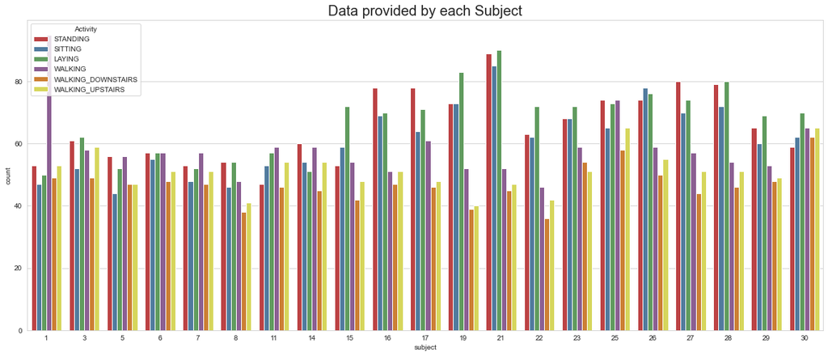

```python
sns.set_style('whitegrid')
plt.figure(figsize=(20,8))
plt.title('Data provided by each Subject', fontsize=20)
sns.countplot(x='subject',hue='Activity', data = inputData1)
plt.show()
```

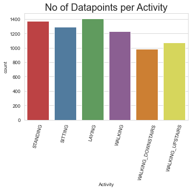

```python
plt.title('No of Datapoints per Activity',fontsize=20)
sns.countplot(inputData1.Activity)
plt.xticks(rotation=75)
plt.show()
```

*Conclusion - Data looks fairly balance across all subjects and Target category variables*

They counts are not exactly equal but we can conclude that the labels are fairly equally distributed adnd that we don't have a very unbalanced dataset.

One curious thing we can see here is the fact that the count of WALKING_UPSTAIRS and WALKING_DOWNSTAIRS is not equal; the participants normally have to walk the same number of stairs down and up and the phone sampling is constant. The only possible conclusion we can make is that generally people walk faster downstairs than upstairs, so the phone has time to register more events when walking upstairs.

## Encode 'Y' column and make it an integer

```python
columns = ['Activity']
#Coonvert 'Activity' column into Category type
inputData1["Activity"] = inputData1["Activity"].astype('category')
inputData1.info(verbose=True,memory_usage='deep',show_counts=True)

cleanup_nums = {"Activity": {"LAYING": 1, "SITTING": 2, "STANDING": 3, "WALKING": 4,
                                  "WALKING_DOWNSTAIRS": 5, "WALKING_UPSTAIRS": 6}}
inputData1 = inputData1.replace(cleanup_nums)

#Coonvert 'Activity' column into Category code
#for col in columns:
#    inputData1[col] = inputData1[col].cat.codes

inputData1.info(verbose=True,memory_usage='deep',show_counts=True)
inputData1.describe(include='all')

# Print all values in a dataframe column
marks_list = inputData1['Activity'].tolist()

# show the list
print(marks_list)
```

```
<class 'pandas.core.frame.DataFrame'>
RangeIndex: 7352 entries, 0 to 7351
Data columns (total 542 columns):
 #    Column                                Non-Null Count  Dtype
---   ------                                --------------  -----
 0    tBodyAcc-mean()-X                     7352 non-null   float64
 1    tBodyAcc-mean()-Y                     7352 non-null   float64
 2    tBodyAcc-mean()-Z                     7352 non-null   float64
 3    tBodyAcc-std()-X                      7352 non-null   float64
 4    tBodyAcc-std()-Y                      7352 non-null   float64
 5    tBodyAcc-std()-Z                      7352 non-null   float64
 6    tBodyAcc-mad()-X                      7352 non-null   float64
 7    tBodyAcc-mad()-Y                      7352 non-null   float64
 8    tBodyAcc-mad()-Z                      7352 non-null   float64
 9    tBodyAcc-max()-X                      7352 non-null   float64
```

[output cut: 1084 more lines]

## Visualize data basis the motion of the Subject i.e. if they are moving or not

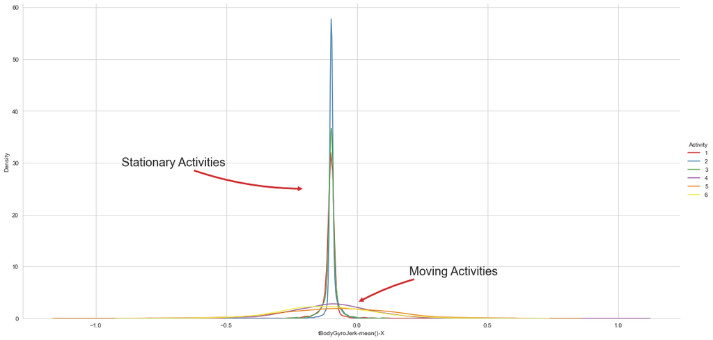

```python
# When in stationary position, the Body Jerks less and hence the Gyroscope Jerks less as well
# This should be able to show up in the data
sns.set_palette("Set1", desat=0.80)
facetgrid = sns.FacetGrid(inputData1[inputData1.columns[~inputData1.columns.isin(['subject'])]], hue='Activity', size=8, aspect=2)
facetgrid.map(sns.distplot,'tBodyGyroJerk-mean()-X', hist=False)\
    .add_legend()

#Annotate graph with stationary activity label
plt.annotate("Stationary Activities", xy=(-0.2,25), xytext=(-0.9, 30), size=20,\
            va='center', ha='left',\
            arrowprops=dict(arrowstyle="simple",connectionstyle="arc3,rad=0.1"))

#Annotate graph with moving activity label
plt.annotate("Moving Activities", xy=(0,3), xytext=(0.2, 9), size=20,\
            va='center', ha='left',\
            arrowprops=dict(arrowstyle="simple",connectionstyle="arc3,rad=0.1"))

plt.show()
```

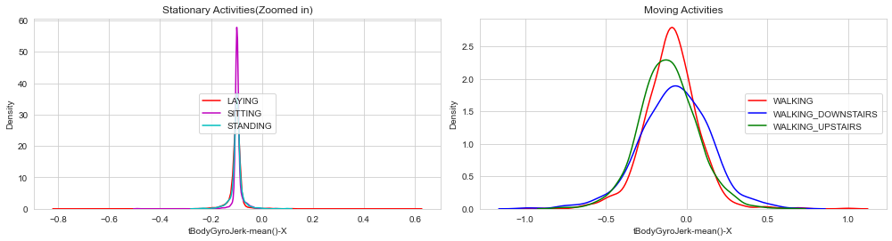

```python
# for plotting purposes taking datapoints of each activity to a different dataframe
df1 = inputData1[inputData1['Activity']==1]
df2 = inputData1[inputData1['Activity']==2]
df3 = inputData1[inputData1['Activity']==3]
df4 = inputData1[inputData1['Activity']==4]
df5 = inputData1[inputData1['Activity']==5]
df6 = inputData1[inputData1['Activity']==6]

plt.figure(figsize=(14,7))
plt.subplot(2,2,1)
plt.title('Stationary Activities(Zoomed in)')
sns.distplot(df1['tBodyGyroJerk-mean()-X'],color = 'r',hist = False, label = 'LAYING')
sns.distplot(df2['tBodyGyroJerk-mean()-X'],color = 'm',hist = False,label = 'SITTING')
sns.distplot(df3['tBodyGyroJerk-mean()-X'],color = 'c',hist = False, label = 'STANDING')
#plt.axis([-1.01, -0.5, 0, 35])
plt.legend(loc='center')

plt.subplot(2,2,2)
plt.title('Moving Activities')
sns.distplot(df4['tBodyGyroJerk-mean()-X'],color = 'red',hist = False, label = 'WALKING')
sns.distplot(df5['tBodyGyroJerk-mean()-X'],color = 'blue',hist = False,label = 'WALKING_DOWNSTAIRS')
sns.distplot(df6['tBodyGyroJerk-mean()-X'],color = 'green',hist = False, label = 'WALKING_UPSTAIRS')
plt.legend(loc='center right')


plt.tight_layout()
plt.show()
```

*t-NSE*

As next step we will try with tSNE is a technique that help us to visualize high-dimesional data (like our case). Read more in the [sklearn docs](https://scikit-learn.org/stable/modules/generated/sklearn.manifold.TSNE.html). Let's see how our data looks when using this and let see how our classifiers score before doing machine learning.

```python
# performs t-sne with different perplexity values and their repective plots..
def perform_tsne(X_data, y_data, perplexities, n_iter=1000, img_name_prefix='t-sne'):

    for index,perplexity in enumerate(perplexities):
        # perform t-sne
        print('\nperforming tsne with perplexity {} and with {} iterations at max'.format(perplexity, n_iter))
        X_reduced = TSNE(verbose=2, perplexity=perplexity).fit_transform(X_data)
        print('Done..')

        # prepare the data for seaborn
        print('Creating plot for this t-sne visualization..')
        df = pd.DataFrame({'x':X_reduced[:,0], 'y':X_reduced[:,1] ,'label':y_data})

        # draw the plot in appropriate place in the grid
        sns.lmplot(data=df, x='x', y='y', hue='label', fit_reg=False, size=8,\
                   palette="Set1",markers=['^','v','s','o', '1','2'])
        plt.title("perplexity : {} and max_iter : {}".format(perplexity, n_iter))
        img_name = img_name_prefix + '_perp_{}_iter_{}.png'.format(perplexity, n_iter)
        print('saving this plot as image in present working directory...')
        plt.savefig(img_name)
        plt.show()
        print('Done')
```

```
performing tsne with perplexity 2 and with 1000 iterations at max
[t-SNE] Computing 7 nearest neighbors...
[t-SNE] Indexed 7352 samples in 0.012s...
[t-SNE] Computed neighbors for 7352 samples in 3.808s...
[t-SNE] Computed conditional probabilities for sample 1000 / 7352
[t-SNE] Computed conditional probabilities for sample 2000 / 7352
[t-SNE] Computed conditional probabilities for sample 3000 / 7352
[t-SNE] Computed conditional probabilities for sample 4000 / 7352
[t-SNE] Computed conditional probabilities for sample 5000 / 7352
[t-SNE] Computed conditional probabilities for sample 6000 / 7352
[t-SNE] Computed conditional probabilities for sample 7000 / 7352
[t-SNE] Computed conditional probabilities for sample 7352 / 7352
[t-SNE] Mean sigma: 0.587012
[t-SNE] Computed conditional probabilities in 0.047s
[t-SNE] Iteration 50: error = 124.8272552, gradient norm = 0.0248051 (50 iterations in 6.117s)
[t-SNE] Iteration 100: error = 107.3635941, gradient norm = 0.0279922 (50 iterations in 4.557s)
[t-SNE] Iteration 150: error = 100.9697800, gradient norm = 0.0195346 (50 iterations in 3.634s)
[t-SNE] Iteration 200: error = 97.5267715, gradient norm = 0.0157398 (50 iterations in 3.949s)
[t-SNE] Iteration 250: error = 95.1766815, gradient norm = 0.0127635 (50 iterations in 3.547s)
[t-SNE] KL divergence after 250 iterations with early exaggeration: 95.176682
[t-SNE] Iteration 300: error = 4.1168022, gradient norm = 0.0015626 (50 iterations in 3.874s)
[t-SNE] Iteration 350: error = 3.2070279, gradient norm = 0.0010105 (50 iterations in 4.637s)
[t-SNE] Iteration 400: error = 2.7763500, gradient norm = 0.0007132 (50 iterations in 4.552s)
[t-SNE] Iteration 450: error = 2.5117457, gradient norm = 0.0005727 (50 iterations in 5.855s)
[t-SNE] Iteration 500: error = 2.3283284, gradient norm = 0.0004791 (50 iterations in 5.573s)
[t-SNE] Iteration 550: error = 2.1907022, gradient norm = 0.0004168 (50 iterations in 5.353s)
[t-SNE] Iteration 600: error = 2.0816123, gradient norm = 0.0003700 (50 iterations in 6.460s)
[t-SNE] Iteration 650: error = 1.9920769, gradient norm = 0.0003302 (50 iterations in 7.261s)
[t-SNE] Iteration 700: error = 1.9163313, gradient norm = 0.0002983 (50 iterations in 6.431s)
[t-SNE] Iteration 750: error = 1.8513191, gradient norm = 0.0002772 (50 iterations in 5.771s)
[t-SNE] Iteration 800: error = 1.7947736, gradient norm = 0.0002554 (50 iterations in 3.983s)
[t-SNE] Iteration 850: error = 1.7445683, gradient norm = 0.0002386 (50 iterations in 4.022s)
[t-SNE] Iteration 900: error = 1.7001044, gradient norm = 0.0002235 (50 iterations in 4.118s)
[t-SNE] Iteration 950: error = 1.6599908, gradient norm = 0.0002098 (50 iterations in 3.724s)
[t-SNE] Iteration 1000: error = 1.6236595, gradient norm = 0.0001959 (50 iterations in 3.646s)
[t-SNE] KL divergence after 1000 iterations: 1.623659
Done..
Creating plot for this t-sne visualization..
saving this plot as image in present working directory...
```

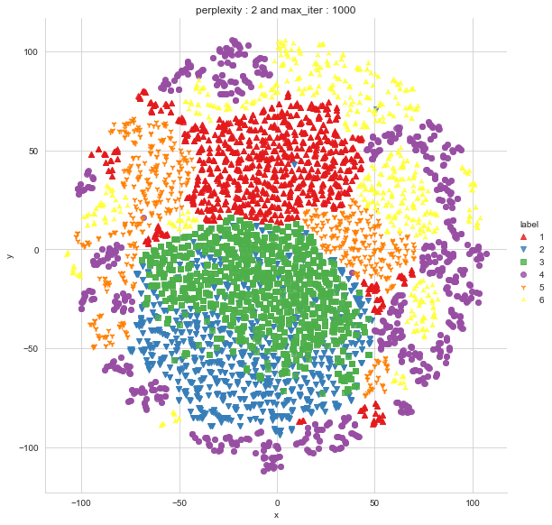

```
Done

performing tsne with perplexity 5 and with 1000 iterations at max
[t-SNE] Computing 16 nearest neighbors...
[t-SNE] Indexed 7352 samples in 0.007s...
[t-SNE] Computed neighbors for 7352 samples in 3.460s...
[t-SNE] Computed conditional probabilities for sample 1000 / 7352
[t-SNE] Computed conditional probabilities for sample 2000 / 7352
[t-SNE] Computed conditional probabilities for sample 3000 / 7352
[t-SNE] Computed conditional probabilities for sample 4000 / 7352
[t-SNE] Computed conditional probabilities for sample 5000 / 7352
[t-SNE] Computed conditional probabilities for sample 6000 / 7352
[t-SNE] Computed conditional probabilities for sample 7000 / 7352
[t-SNE] Computed conditional probabilities for sample 7352 / 7352
[t-SNE] Mean sigma: 0.950594
[t-SNE] Computed conditional probabilities in 0.116s
[t-SNE] Iteration 50: error = 113.9028244, gradient norm = 0.0230854 (50 iterations in 5.868s)
[t-SNE] Iteration 100: error = 97.2432632, gradient norm = 0.0163591 (50 iterations in 4.313s)
[t-SNE] Iteration 150: error = 92.9567871, gradient norm = 0.0085301 (50 iterations in 3.879s)
[t-SNE] Iteration 200: error = 91.0596466, gradient norm = 0.0064298 (50 iterations in 3.630s)
[t-SNE] Iteration 250: error = 89.9264297, gradient norm = 0.0053998 (50 iterations in 3.568s)
[t-SNE] KL divergence after 250 iterations with early exaggeration: 89.926430
[t-SNE] Iteration 300: error = 3.5717468, gradient norm = 0.0014674 (50 iterations in 3.581s)
[t-SNE] Iteration 350: error = 2.8119791, gradient norm = 0.0007565 (50 iterations in 3.556s)
[t-SNE] Iteration 400: error = 2.4301438, gradient norm = 0.0005202 (50 iterations in 3.664s)
[t-SNE] Iteration 450: error = 2.2120295, gradient norm = 0.0004025 (50 iterations in 3.718s)
[t-SNE] Iteration 500: error = 2.0668409, gradient norm = 0.0003338 (50 iterations in 3.646s)
[t-SNE] Iteration 550: error = 1.9612737, gradient norm = 0.0002834 (50 iterations in 3.753s)
[t-SNE] Iteration 600: error = 1.8799081, gradient norm = 0.0002563 (50 iterations in 3.616s)
[t-SNE] Iteration 650: error = 1.8153403, gradient norm = 0.0002193 (50 iterations in 3.751s)
[t-SNE] Iteration 700: error = 1.7619271, gradient norm = 0.0001965 (50 iterations in 3.631s)
[t-SNE] Iteration 750: error = 1.7165539, gradient norm = 0.0001794 (50 iterations in 3.612s)
[t-SNE] Iteration 800: error = 1.6776476, gradient norm = 0.0001658 (50 iterations in 3.802s)
[t-SNE] Iteration 850: error = 1.6438664, gradient norm = 0.0001523 (50 iterations in 4.622s)
[t-SNE] Iteration 900: error = 1.6140404, gradient norm = 0.0001437 (50 iterations in 4.441s)
[t-SNE] Iteration 950: error = 1.5879183, gradient norm = 0.0001354 (50 iterations in 4.494s)
[t-SNE] Iteration 1000: error = 1.5646554, gradient norm = 0.0001268 (50 iterations in 4.182s)
[t-SNE] KL divergence after 1000 iterations: 1.564655
Done..
Creating plot for this t-sne visualization..
saving this plot as image in present working directory...
```

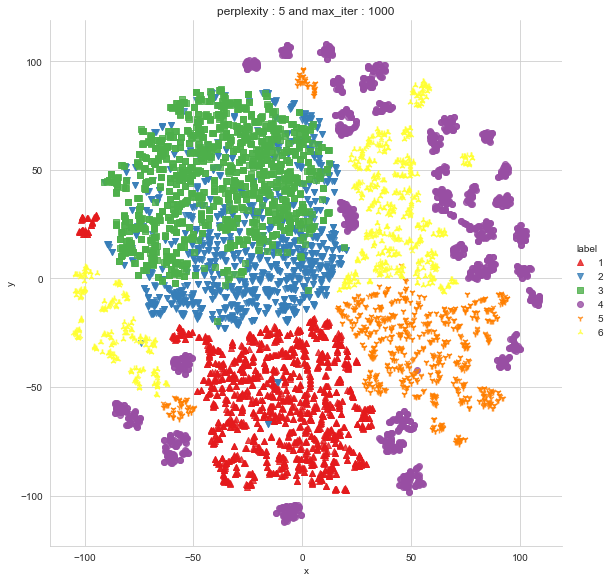

```
Done

performing tsne with perplexity 10 and with 1000 iterations at max
[t-SNE] Computing 31 nearest neighbors...
[t-SNE] Indexed 7352 samples in 0.017s...
[t-SNE] Computed neighbors for 7352 samples in 4.576s...
[t-SNE] Computed conditional probabilities for sample 1000 / 7352
[t-SNE] Computed conditional probabilities for sample 2000 / 7352
[t-SNE] Computed conditional probabilities for sample 3000 / 7352
[t-SNE] Computed conditional probabilities for sample 4000 / 7352
[t-SNE] Computed conditional probabilities for sample 5000 / 7352
[t-SNE] Computed conditional probabilities for sample 6000 / 7352
[t-SNE] Computed conditional probabilities for sample 7000 / 7352
[t-SNE] Computed conditional probabilities for sample 7352 / 7352
[t-SNE] Mean sigma: 1.121522
[t-SNE] Computed conditional probabilities in 0.244s
[t-SNE] Iteration 50: error = 106.0583954, gradient norm = 0.0144595 (50 iterations in 8.419s)
[t-SNE] Iteration 100: error = 90.6586761, gradient norm = 0.0112418 (50 iterations in 5.637s)
[t-SNE] Iteration 150: error = 87.4804306, gradient norm = 0.0069058 (50 iterations in 5.597s)
[t-SNE] Iteration 200: error = 86.2228394, gradient norm = 0.0052665 (50 iterations in 7.107s)
[t-SNE] Iteration 250: error = 85.5189362, gradient norm = 0.0031330 (50 iterations in 6.484s)
[t-SNE] KL divergence after 250 iterations with early exaggeration: 85.518936
[t-SNE] Iteration 300: error = 3.1331398, gradient norm = 0.0013821 (50 iterations in 6.377s)
[t-SNE] Iteration 350: error = 2.4922023, gradient norm = 0.0006498 (50 iterations in 5.679s)
[t-SNE] Iteration 400: error = 2.1738853, gradient norm = 0.0004221 (50 iterations in 5.909s)
[t-SNE] Iteration 450: error = 1.9902651, gradient norm = 0.0003123 (50 iterations in 5.595s)
[t-SNE] Iteration 500: error = 1.8724337, gradient norm = 0.0002481 (50 iterations in 5.624s)
[t-SNE] Iteration 550: error = 1.7895956, gradient norm = 0.0002108 (50 iterations in 5.844s)
[t-SNE] Iteration 600: error = 1.7271926, gradient norm = 0.0001800 (50 iterations in 5.746s)
[t-SNE] Iteration 650: error = 1.6781420, gradient norm = 0.0001599 (50 iterations in 5.908s)
[t-SNE] Iteration 700: error = 1.6385654, gradient norm = 0.0001418 (50 iterations in 5.668s)
[t-SNE] Iteration 750: error = 1.6061373, gradient norm = 0.0001302 (50 iterations in 5.673s)
[t-SNE] Iteration 800: error = 1.5789158, gradient norm = 0.0001176 (50 iterations in 5.820s)
[t-SNE] Iteration 850: error = 1.5555048, gradient norm = 0.0001107 (50 iterations in 5.579s)
[t-SNE] Iteration 900: error = 1.5354583, gradient norm = 0.0001027 (50 iterations in 5.821s)
[t-SNE] Iteration 950: error = 1.5181173, gradient norm = 0.0000977 (50 iterations in 5.910s)
[t-SNE] Iteration 1000: error = 1.5029721, gradient norm = 0.0000908 (50 iterations in 5.995s)
[t-SNE] KL divergence after 1000 iterations: 1.502972
Done..
Creating plot for this t-sne visualization..
saving this plot as image in present working directory...
```

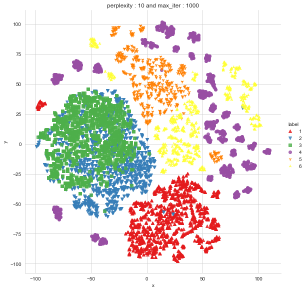

```
Done

performing tsne with perplexity 20 and with 1000 iterations at max
[t-SNE] Computing 61 nearest neighbors...
[t-SNE] Indexed 7352 samples in 0.013s...
[t-SNE] Computed neighbors for 7352 samples in 5.777s...
[t-SNE] Computed conditional probabilities for sample 1000 / 7352
[t-SNE] Computed conditional probabilities for sample 2000 / 7352
[t-SNE] Computed conditional probabilities for sample 3000 / 7352
[t-SNE] Computed conditional probabilities for sample 4000 / 7352
[t-SNE] Computed conditional probabilities for sample 5000 / 7352
[t-SNE] Computed conditional probabilities for sample 6000 / 7352
[t-SNE] Computed conditional probabilities for sample 7000 / 7352
[t-SNE] Computed conditional probabilities for sample 7352 / 7352
[t-SNE] Mean sigma: 1.261088
[t-SNE] Computed conditional probabilities in 0.546s
[t-SNE] Iteration 50: error = 97.2526093, gradient norm = 0.0204451 (50 iterations in 10.137s)
[t-SNE] Iteration 100: error = 84.4077148, gradient norm = 0.0081383 (50 iterations in 7.555s)
[t-SNE] Iteration 150: error = 82.2126617, gradient norm = 0.0037826 (50 iterations in 7.487s)
[t-SNE] Iteration 200: error = 81.4077759, gradient norm = 0.0028347 (50 iterations in 7.017s)
[t-SNE] Iteration 250: error = 80.9718628, gradient norm = 0.0023671 (50 iterations in 7.689s)
[t-SNE] KL divergence after 250 iterations with early exaggeration: 80.971863
[t-SNE] Iteration 300: error = 2.7004056, gradient norm = 0.0013053 (50 iterations in 6.881s)
[t-SNE] Iteration 350: error = 2.1657748, gradient norm = 0.0005762 (50 iterations in 6.522s)
[t-SNE] Iteration 400: error = 1.9165580, gradient norm = 0.0003469 (50 iterations in 6.582s)
[t-SNE] Iteration 450: error = 1.7705126, gradient norm = 0.0002494 (50 iterations in 6.704s)
[t-SNE] Iteration 500: error = 1.6765776, gradient norm = 0.0001926 (50 iterations in 6.579s)
[t-SNE] Iteration 550: error = 1.6122303, gradient norm = 0.0001588 (50 iterations in 6.652s)
[t-SNE] Iteration 600: error = 1.5654777, gradient norm = 0.0001347 (50 iterations in 6.745s)
[t-SNE] Iteration 650: error = 1.5301771, gradient norm = 0.0001194 (50 iterations in 6.691s)
[t-SNE] Iteration 700: error = 1.5028113, gradient norm = 0.0001072 (50 iterations in 6.561s)
[t-SNE] Iteration 750: error = 1.4811954, gradient norm = 0.0000975 (50 iterations in 6.749s)
[t-SNE] Iteration 800: error = 1.4639556, gradient norm = 0.0000908 (50 iterations in 6.593s)
[t-SNE] Iteration 850: error = 1.4501673, gradient norm = 0.0000879 (50 iterations in 6.854s)
[t-SNE] Iteration 900: error = 1.4389955, gradient norm = 0.0000832 (50 iterations in 6.690s)
[t-SNE] Iteration 950: error = 1.4294074, gradient norm = 0.0000793 (50 iterations in 6.625s)
[t-SNE] Iteration 1000: error = 1.4211944, gradient norm = 0.0000755 (50 iterations in 6.607s)
[t-SNE] KL divergence after 1000 iterations: 1.421194
Done..
Creating plot for this t-sne visualization..
saving this plot as image in present working directory...
```

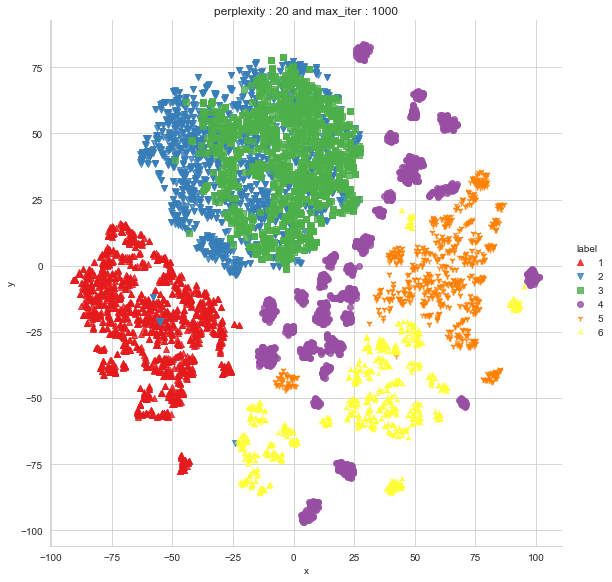

```
Done

performing tsne with perplexity 50 and with 1000 iterations at max
[t-SNE] Computing 151 nearest neighbors...
[t-SNE] Indexed 7352 samples in 0.010s...
[t-SNE] Computed neighbors for 7352 samples in 5.567s...
[t-SNE] Computed conditional probabilities for sample 1000 / 7352
[t-SNE] Computed conditional probabilities for sample 2000 / 7352
[t-SNE] Computed conditional probabilities for sample 3000 / 7352
[t-SNE] Computed conditional probabilities for sample 4000 / 7352
[t-SNE] Computed conditional probabilities for sample 5000 / 7352
[t-SNE] Computed conditional probabilities for sample 6000 / 7352
[t-SNE] Computed conditional probabilities for sample 7000 / 7352
[t-SNE] Computed conditional probabilities for sample 7352 / 7352
[t-SNE] Mean sigma: 1.423198
[t-SNE] Computed conditional probabilities in 1.882s
[t-SNE] Iteration 50: error = 83.4552841, gradient norm = 0.0333946 (50 iterations in 11.974s)
[t-SNE] Iteration 100: error = 75.6348343, gradient norm = 0.0038365 (50 iterations in 10.440s)
[t-SNE] Iteration 150: error = 74.7708054, gradient norm = 0.0025986 (50 iterations in 9.206s)
[t-SNE] Iteration 200: error = 74.4228210, gradient norm = 0.0014215 (50 iterations in 9.150s)
[t-SNE] Iteration 250: error = 74.2443542, gradient norm = 0.0012811 (50 iterations in 8.979s)
[t-SNE] KL divergence after 250 iterations with early exaggeration: 74.244354
[t-SNE] Iteration 300: error = 2.1626101, gradient norm = 0.0011801 (50 iterations in 8.781s)
[t-SNE] Iteration 350: error = 1.7630271, gradient norm = 0.0004873 (50 iterations in 8.241s)
[t-SNE] Iteration 400: error = 1.5943384, gradient norm = 0.0002788 (50 iterations in 7.708s)
[t-SNE] Iteration 450: error = 1.5007391, gradient norm = 0.0001895 (50 iterations in 6.088s)
[t-SNE] Iteration 500: error = 1.4408095, gradient norm = 0.0001403 (50 iterations in 5.623s)
[t-SNE] Iteration 550: error = 1.3996854, gradient norm = 0.0001118 (50 iterations in 6.786s)
[t-SNE] Iteration 600: error = 1.3704144, gradient norm = 0.0000968 (50 iterations in 6.063s)
[t-SNE] Iteration 650: error = 1.3495927, gradient norm = 0.0000835 (50 iterations in 5.299s)
[t-SNE] Iteration 700: error = 1.3342590, gradient norm = 0.0000755 (50 iterations in 5.319s)
[t-SNE] Iteration 750: error = 1.3225195, gradient norm = 0.0000702 (50 iterations in 5.555s)
[t-SNE] Iteration 800: error = 1.3137828, gradient norm = 0.0000655 (50 iterations in 6.119s)
[t-SNE] Iteration 850: error = 1.3066735, gradient norm = 0.0000627 (50 iterations in 5.792s)
[t-SNE] Iteration 900: error = 1.3008209, gradient norm = 0.0000592 (50 iterations in 5.482s)
[t-SNE] Iteration 950: error = 1.2959931, gradient norm = 0.0000564 (50 iterations in 5.672s)
[t-SNE] Iteration 1000: error = 1.2917923, gradient norm = 0.0000539 (50 iterations in 7.145s)
[t-SNE] KL divergence after 1000 iterations: 1.291792
Done..
Creating plot for this t-sne visualization..
saving this plot as image in present working directory...
```

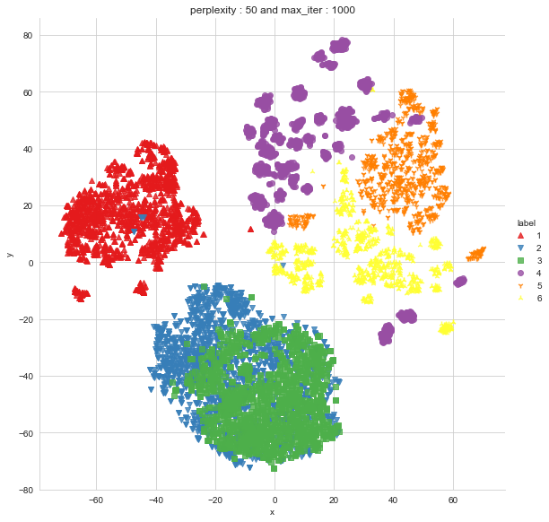

```
Done
```

```python
X_pre_tsne = inputData1[inputData1.columns[~inputData1.columns.isin(['subject','Activity'])]]
y_pre_tsne = inputData1['Activity']
perform_tsne(X_data = X_pre_tsne,y_data=y_pre_tsne, perplexities =[2,5,10,20,50])
```

## Split Predictor and Target Varaibles

```python
X = inputData1.loc[:, ~inputData1.columns.isin(['Activity'])]
X
```

|  | tBodyAcc-mean()-X | tBodyAcc-mean()-Y | tBodyAcc-mean()-Z | tBodyAcc-std()-X | tBodyAcc-std()-Y | tBodyAcc-std()-Z | tBodyAcc-mad()-X | tBodyAcc-mad()-Y | tBodyAcc-mad()-Z | tBodyAcc-max()-X | ... | fBodyBodyGyroJerkMag-skewness() | fBodyBodyGyroJerkMag-kurtosis() | angle(tBodyAccMean,gravity) | angle(tBodyAccJerkMean),gravityMean) | angle(tBodyGyroMean,gravityMean) | angle(tBodyGyroJerkMean,gravityMean) | angle(X,gravityMean) | angle(Y,gravityMean) | angle(Z,gravityMean) | subject |
| --- | --- | --- | --- | --- | --- | --- | --- | --- | --- | --- | --- | --- | --- | --- | --- | --- | --- | --- | --- | --- | --- |
| 0 | 0.288585 | -0.020294 | -0.132905 | -0.995279 | -0.983111 | -0.913526 | -0.995112 | -0.983185 | -0.923527 | -0.934724 | ... | -0.298676 | -0.710304 | -0.112754 | 0.030400 | -0.464761 | -0.018446 | -0.841247 | 0.179941 | -0.058627 | 1 |
| 1 | 0.278419 | -0.016411 | -0.123520 | -0.998245 | -0.975300 | -0.960322 | -0.998807 | -0.974914 | -0.957686 | -0.943068 | ... | -0.595051 | -0.861499 | 0.053477 | -0.007435 | -0.732626 | 0.703511 | -0.844788 | 0.180289 | -0.054317 | 1 |
| 2 | 0.279653 | -0.019467 | -0.113462 | -0.995380 | -0.967187 | -0.978944 | -0.996520 | -0.963668 | -0.977469 | -0.938692 | ... | -0.390748 | -0.760104 | -0.118559 | 0.177899 | 0.100699 | 0.808529 | -0.848933 | 0.180637 | -0.049118 | 1 |
| 3 | 0.279174 | -0.026201 | -0.123283 | -0.996091 | -0.983403 | -0.990675 | -0.997099 | -0.982750 | -0.989302 | -0.938692 | ... | -0.117290 | -0.482845 | -0.036788 | -0.012892 | 0.640011 | -0.485366 | -0.848649 | 0.181935 | -0.047663 | 1 |
| 4 | 0.276629 | -0.016570 | -0.115362 | -0.998139 | -0.980817 | -0.990482 | -0.998321 | -0.979672 | -0.990441 | -0.942469 | ... | -0.351471 | -0.699205 | 0.123320 | 0.122542 | 0.693578 | -0.615971 | -0.847865 | 0.185151 | -0.043892 | 1 |
| ... | ... | ... | ... | ... | ... | ... | ... | ... | ... | ... | ... | ... | ... | ... | ... | ... | ... | ... | ... | ... | ... |
| 7347 | 0.299665 | -0.057193 | -0.181233 | -0.195387 | 0.039905 | 0.077078 | -0.282301 | 0.043616 | 0.060410 | 0.210795 | ... | -0.588433 | -0.880324 | -0.190437 | 0.829718 | 0.206972 | -0.425619 | -0.791883 | 0.238604 | 0.049819 | 30 |
| 7348 | 0.273853 | -0.007749 | -0.147468 | -0.235309 | 0.004816 | 0.059280 | -0.322552 | -0.029456 | 0.080585 | 0.117440 | ... | -0.390738 | -0.680744 | 0.064907 | 0.875679 | -0.879033 | 0.400219 | -0.771840 | 0.252676 | 0.050053 | 30 |
| 7349 | 0.273387 | -0.017011 | -0.045022 | -0.218218 | -0.103822 | 0.274533 | -0.304515 | -0.098913 | 0.332584 | 0.043999 | ... | 0.025145 | -0.304029 | 0.052806 | -0.266724 | 0.864404 | 0.701169 | -0.779133 | 0.249145 | 0.040811 | 30 |
| 7350 | 0.289654 | -0.018843 | -0.158281 | -0.219139 | -0.111412 | 0.268893 | -0.310487 | -0.068200 | 0.319473 | 0.101702 | ... | 0.063907 | -0.344314 | -0.101360 | 0.700740 | 0.936674 | -0.589479 | -0.785181 | 0.246432 | 0.025339 | 30 |
| 7351 | 0.351503 | -0.012423 | -0.203867 | -0.269270 | -0.087212 | 0.177404 | -0.377404 | -0.038678 | 0.229430 | 0.269013 | ... | -0.387052 | -0.740738 | -0.280088 | -0.007739 | -0.056088 | -0.616956 | -0.783267 | 0.246809 | 0.036695 | 30 |

7352 rows × 541 columns

```python
y = inputData1['Activity']
y
```

```
0       3
1       3
2       3
3       3
4       3
       ..
7347    6
7348    6
7349    6
7350    6
7351    6
Name: Activity, Length: 7352, dtype: category
Categories (6, int64): [1, 2, 3, 4, 5, 6]
```

## Split Training and Testing Data Set

```python
X_train,X_test,y_train,y_test = train_test_split(X, y, test_size=0.3, random_state=42, stratify=y)

X_train.head(5)
```

|  | tBodyAcc-mean()-X | tBodyAcc-mean()-Y | tBodyAcc-mean()-Z | tBodyAcc-std()-X | tBodyAcc-std()-Y | tBodyAcc-std()-Z | tBodyAcc-mad()-X | tBodyAcc-mad()-Y | tBodyAcc-mad()-Z | tBodyAcc-max()-X | ... | fBodyBodyGyroJerkMag-skewness() | fBodyBodyGyroJerkMag-kurtosis() | angle(tBodyAccMean,gravity) | angle(tBodyAccJerkMean),gravityMean) | angle(tBodyGyroMean,gravityMean) | angle(tBodyGyroJerkMean,gravityMean) | angle(X,gravityMean) | angle(Y,gravityMean) | angle(Z,gravityMean) | subject |
| --- | --- | --- | --- | --- | --- | --- | --- | --- | --- | --- | --- | --- | --- | --- | --- | --- | --- | --- | --- | --- | --- |
| 6817 | 0.278846 | -0.013899 | -0.108009 | -0.994649 | -0.927216 | -0.974903 | -0.996288 | -0.934896 | -0.974012 | -0.926403 | ... | -0.331124 | -0.747509 | -0.026145 | 0.184038 | 0.870878 | 0.105710 | -0.898993 | 0.167367 | 0.028030 | 29 |
| 375 | 0.279529 | -0.016447 | -0.106264 | -0.997564 | -0.991056 | -0.993859 | -0.998093 | -0.991079 | -0.994048 | -0.940746 | ... | -0.902791 | -0.977257 | -0.248734 | 0.611192 | 0.621399 | -0.507541 | -0.679571 | 0.309573 | -0.048540 | 3 |
| 5233 | 0.232215 | -0.018625 | -0.059943 | -0.371774 | -0.289589 | -0.549180 | -0.398854 | -0.322288 | -0.556230 | -0.275857 | ... | -0.276216 | -0.693419 | 0.146482 | -0.893620 | -0.959505 | -0.475998 | -0.686762 | 0.124930 | -0.206962 | 25 |
| 644 | 0.278546 | -0.018913 | -0.038706 | -0.173239 | -0.256429 | -0.334349 | -0.233815 | -0.312155 | -0.273396 | 0.204967 | ... | -0.068279 | -0.411694 | 0.053125 | 0.617638 | -0.945883 | -0.879009 | -0.792673 | 0.226944 | 0.082793 | 3 |
| 158 | 0.140859 | -0.068262 | -0.072116 | -0.234499 | -0.079449 | -0.033664 | -0.297363 | -0.067637 | -0.003289 | -0.084350 | ... | -0.642779 | -0.893863 | 0.335031 | -0.817833 | -0.963267 | -0.904299 | -0.697662 | 0.301654 | 0.065570 | 1 |

5 rows × 541 columns

```python
X_test.head(5)
```

|  | tBodyAcc-mean()-X | tBodyAcc-mean()-Y | tBodyAcc-mean()-Z | tBodyAcc-std()-X | tBodyAcc-std()-Y | tBodyAcc-std()-Z | tBodyAcc-mad()-X | tBodyAcc-mad()-Y | tBodyAcc-mad()-Z | tBodyAcc-max()-X | ... | fBodyBodyGyroJerkMag-skewness() | fBodyBodyGyroJerkMag-kurtosis() | angle(tBodyAccMean,gravity) | angle(tBodyAccJerkMean),gravityMean) | angle(tBodyGyroMean,gravityMean) | angle(tBodyGyroJerkMean,gravityMean) | angle(X,gravityMean) | angle(Y,gravityMean) | angle(Z,gravityMean) | subject |
| --- | --- | --- | --- | --- | --- | --- | --- | --- | --- | --- | --- | --- | --- | --- | --- | --- | --- | --- | --- | --- | --- |
| 3527 | 0.267166 | -0.022671 | -0.099358 | -0.992399 | -0.988213 | -0.986525 | -0.993607 | -0.988376 | -0.986539 | -0.942042 | ... | -0.252199 | -0.512276 | 0.137679 | 0.014576 | 0.428461 | 0.458337 | 0.404604 | -0.540792 | -0.439086 | 17 |
| 512 | 0.136697 | -0.055384 | -0.191091 | -0.218841 | 0.046486 | -0.256952 | -0.315962 | 0.021862 | -0.195389 | -0.126466 | ... | -0.162244 | -0.528942 | 0.263811 | 0.030869 | 0.962317 | -0.199382 | -0.637021 | 0.335781 | 0.098056 | 3 |
| 6853 | 0.279693 | -0.017105 | -0.106392 | -0.995717 | -0.984895 | -0.986676 | -0.996740 | -0.983539 | -0.986108 | -0.930743 | ... | -0.724916 | -0.926851 | -0.522504 | -0.361006 | -0.307842 | -0.075709 | -0.697798 | -0.036752 | -0.149849 | 29 |
| 5152 | 0.261018 | 0.094467 | -0.118669 | -0.975008 | -0.519832 | -0.958154 | -0.975836 | -0.496527 | -0.956347 | -0.917692 | ... | -0.082039 | -0.421262 | 0.064497 | 0.026419 | 0.027985 | 0.152673 | 0.932997 | 0.134853 | -0.879122 | 25 |
| 3540 | 0.239954 | -0.014767 | -0.053588 | -0.304710 | 0.019941 | -0.294556 | -0.327785 | -0.022903 | -0.305531 | -0.077962 | ... | 0.231058 | -0.140493 | 0.352722 | -0.624337 | 0.759510 | -0.143668 | -0.702384 | 0.280569 | 0.114628 | 17 |

5 rows × 541 columns

```python
y_train.head(5)
```

```
6817    3
375     3
5233    5
644     5
158     6
Name: Activity, dtype: category
Categories (6, int64): [1, 2, 3, 4, 5, 6]
```

```python
y_test.head(5)
```

```
3527    1
512     6
6853    2
5152    1
3540    4
Name: Activity, dtype: category
Categories (6, int64): [1, 2, 3, 4, 5, 6]
```

## Standardize the Variables

```python
# Scaling the data
scaler = MinMaxScaler()
X_train_scaled = scaler.fit_transform(X_train)
X_test_scaled = scaler.transform(X_test) # Note I don't fit_transform on test set
```

# Train Model using different variations of NB and Logistic Regression [Marks:2]

```python
labels=['LAYING', 'SITTING','STANDING','WALKING','WALKING_DOWNSTAIRS','WALKING_UPSTAIRS']
```

```python
### Create Array to store results
# create a Feature_Subset_Result array
dFFeature_Subset_Result = pd.DataFrame(columns=['Best Estimator', 'Model', 'Training Time', 'Testing Time', 'Overall Accuracy of Model',
                                                'Confusion Matrix', 'Classifiction Report', 'Parameters of best estimator',
                                                'Average Cross Validate scores of best estimator',
                                                'Total number of cross validation sets','FPR','TPR','P_FPR','P_TPR'])
Feature_Subset_Result = []
```

### Function to plot Confusion Matrix

```python
from sklearn.metrics import confusion_matrix
plt.rcParams["font.family"] = 'DejaVu Sans'

def plot_confusion_matrix(cm, classes, normalize=False, title='Confusion Matrix', cmap=plt.cm.Blues):
    if normalize:
        cm = cm.astype('float') / cm.sum(axis=1)[:, np.newaxis]

    plt.imshow(cm, interpolation='nearest', cmap=cmap)
    plt.title(title)
    plt.colorbar()
    tick_marks = np.arange(len(classes))
    plt.xticks(tick_marks, classes, rotation=90)
    plt.yticks(tick_marks, classes)

    fmt = '.2f' if normalize else 'd'
    thresh = cm.max() / 2.
    for i, j in itertools.product(range(cm.shape[0]), range(cm.shape[1])):
        plt.text(j, i, format(cm[i, j], fmt),
                 horizontalalignment="center",
                 color="white" if cm[i, j] > thresh else "black")

    plt.tight_layout()
    plt.ylabel('True label')
    plt.xlabel('Predicted label')
```

### Generic function to run any model specified

```python
from datetime import datetime
def perform_model(model, X_train, y_train, X_test, y_test, class_labels, cm_normalize=True, \
                 print_cm=True, cm_cmap=plt.cm.Greens):


    # to store results at various phases
    results = dict()

    # time at which model starts training
    train_start_time = datetime.now()
    print('training the model..')
    model.fit(X_train, y_train)
    print('Done \n \n')
    train_end_time = datetime.now()
    results['training_time'] =  train_end_time - train_start_time
    print('training_time(HH:MM:SS.ms) - {}\n\n'.format(results['training_time']))
    results['model_name_'] = str(model)


    # predict test data
    print('Predicting test data')
    test_start_time = datetime.now()
    y_pred = model.predict(X_test)
    test_end_time = datetime.now()
    print('Done \n \n')
    results['testing_time'] = test_end_time - test_start_time
    print('testing time(HH:MM:SS:ms) - {}\n\n'.format(results['testing_time']))
    results['predicted'] = y_pred


    # calculate overall accuracty of the model
    accuracy = metrics.accuracy_score(y_true=y_test, y_pred=y_pred)
    # store accuracy in results
    results['accuracy'] = accuracy
    print('---------------------')
    print('|      Accuracy      |')
    print('---------------------')
    print('\n    {}\n\n'.format(accuracy))

    # confusion matrix
    cm = metrics.confusion_matrix(y_test, y_pred)
    results['confusion_matrix'] = cm
    if print_cm:
        print('--------------------')
        print('| Confusion Matrix |')
        print('--------------------')
        print('\n {}'.format(cm))

    # plot confusin matrix
    plt.figure(figsize=(8,8))
    plt.grid(b=False)
    #print(class_labels)
    plot_confusion_matrix(cm, class_labels, normalize=True, title='Normalized confusion matrix', cmap = cm_cmap)
    plt.show()

    # get classification report
    print('-------------------------')
    print('| Classifiction Report |')
    print('-------------------------')
    classification_report = metrics.classification_report(y_test, y_pred)
    # store report in results
    results['classification_report'] = classification_report
    print(classification_report)

    # get ROC Score and Curve
    print('-------------------------')
    print('| ROC Curve |')
    print('-------------------------')
    # predict probabilities
    pred_prob = model.predict_proba(X_test)
    # roc curve for models
    fpr, tpr, thresh = roc_curve(y_test, pred_prob[:,1], pos_label=2)
    results['fpr'] = fpr
    results['tpr'] = tpr
    # roc curve for tpr = fpr (blue line with 50% area)
    random_probs = [0 for i in range(len(y_test))]
    p_fpr, p_tpr, _ = roc_curve(y_test, random_probs, pos_label=1)
    results['p_fpr'] = p_fpr
    results['p_tpr'] = p_tpr
    # auc scores
    # auc_score = roc_auc_score(y_test, pred_prob[:,1])
    # plot roc curves
    plt.plot(fpr, tpr, linestyle='--',color='orange', label="")
    plt.plot(p_fpr, p_tpr, linestyle='--', color='blue')
    # title
    plt.title('ROC curve')
    # x label
    plt.xlabel('False Positive Rate')
    # y label
    plt.ylabel('True Positive rate')
    plt.legend(loc='best')
    plt.savefig('ROC',dpi=300)
    plt.rcParams['figure.figsize'] = [10, 6]
    plt.show();

    # add the trained  model to the results
    results['model'] = model

    return results
```

### Method to print the gridsearch Attributes

```python
def print_grid_search_attributes(log_reg_grid_results):
    model = log_reg_grid_results['model']

    # Estimator that gave highest score among all the estimators formed in GridSearch
    print('--------------------------')
    print('|      Best Estimator     |')
    print('--------------------------')
    print('\n\t{}\n'.format(model.best_estimator_))


    # parameters that gave best results while performing grid search
    print('--------------------------')
    print('|     Best parameters     |')
    print('--------------------------')
    print('\tParameters of best estimator : \n\n\t{}\n'.format(model.best_params_))


    #  number of cross validation splits
    print('---------------------------------')
    print('|   No of CrossValidation sets   |')
    print('--------------------------------')
    print('\n\tTotal number of cross validation sets: {}\n'.format(model.n_splits_))


    # Average cross validated score of the best estimator, from the Grid Search
    print('--------------------------')
    print('|        Best Score       |')
    print('--------------------------')
    print('\n\tAverage Cross Validate scores of best estimator : \n\n\t{}\n'.format(model.best_score_))

    Feature_Subset_Result.append((model.best_estimator_, str(model), log_reg_grid_results['training_time'],  log_reg_grid_results['testing_time'],
                                  log_reg_grid_results['accuracy'], log_reg_grid_results['confusion_matrix'],
                                  log_reg_grid_results['classification_report'],
                                  model.best_params_, model.best_score_, model.n_splits_, log_reg_grid_results['fpr'], log_reg_grid_results['tpr'],
                                  log_reg_grid_results['p_fpr'], log_reg_grid_results['p_tpr']))
```

## 1. Logistic Regression with Grid Search

```
training the model..
Fitting 3 folds for each of 60 candidates, totalling 180 fits
Done


training_time(HH:MM:SS.ms) - 0:11:07.399354


Predicting test data
Done


testing time(HH:MM:SS:ms) - 0:00:00.008994


---------------------
|      Accuracy      |
---------------------

    0.985494106980961


--------------------
| Confusion Matrix |
--------------------

 [[422   0   0   0   0   0]
 [  0 369  17   0   0   0]
 [  0  14 398   0   0   0]
 [  0   0   0 368   0   0]
 [  0   0   0   0 296   0]
 [  0   0   0   1   0 321]]
```

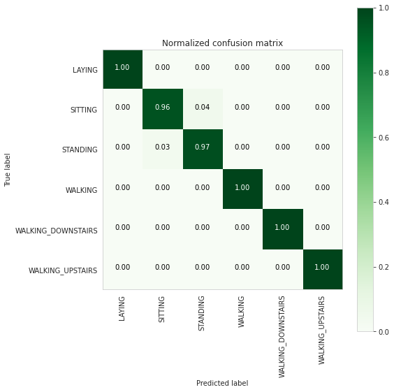

```
No artists with labels found to put in legend.  Note that artists whose label start with an underscore are ignored when legend() is called with no argument.
```

```
-------------------------
| Classifiction Report |
-------------------------
              precision    recall  f1-score   support

           1       1.00      1.00      1.00       422
           2       0.96      0.96      0.96       386
           3       0.96      0.97      0.96       412
           4       1.00      1.00      1.00       368
           5       1.00      1.00      1.00       296
           6       1.00      1.00      1.00       322

    accuracy                           0.99      2206
   macro avg       0.99      0.99      0.99      2206
weighted avg       0.99      0.99      0.99      2206

-------------------------
| ROC Curve |
-------------------------
```

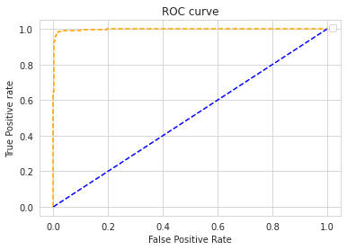

```
--------------------------
|      Best Estimator     |
--------------------------

	LogisticRegression(C=10, solver='liblinear')

--------------------------
|     Best parameters     |
--------------------------
	Parameters of best estimator :

	{'C': 10, 'penalty': 'l2', 'solver': 'liblinear'}

---------------------------------
|   No of CrossValidation sets   |
--------------------------------

	Total number of cross validation sets: 3

--------------------------
|        Best Score       |
--------------------------

	Average Cross Validate scores of best estimator :

	0.9827051633174082
```

```python
# start Grid search with scaled data
parameters = {'C':[0.01, 0.1, 1, 10, 20, 30], 'penalty':['l2','l1'], 'solver':['newton-cg', 'lbfgs', 'liblinear', 'sag', 'saga']}
#parameters = {'C':[0.01, 0.1, 1, 10, 20, 30], 'penalty':['l2','l1','elasticnet','none'], 'dual':[True,False], 'tol':[1e-4], 'fit_intercept':[True,False], 'intercept_scaling':[1,2,5,10],
#              'class_weight':[None,'balanced'], 'solver':['newton-cg', 'lbfgs', 'liblinear', 'sag', 'saga'], 'max_iter':[100]}
log_reg = linear_model.LogisticRegression()
log_reg_grid = GridSearchCV(log_reg, param_grid=parameters, cv=3, verbose=1, n_jobs=-1)
log_reg_grid_results = perform_model(log_reg_grid, X_train_scaled, y_train, X_test_scaled, y_test, labels)
# observe the attributes of the model
print_grid_search_attributes(log_reg_grid_results)
```

## 2. Naive Bayes with GaussianNB and Grid Search

```
training the model..
Fitting 3 folds for each of 100 candidates, totalling 300 fits
Done


training_time(HH:MM:SS.ms) - 0:00:39.714497


Predicting test data
Done


testing time(HH:MM:SS:ms) - 0:00:00.160908


---------------------
|      Accuracy      |
---------------------

    0.8349954669084315


--------------------
| Confusion Matrix |
--------------------

 [[418   0   0   0   0   4]
 [  4 220 162   0   0   0]
 [  0   9 403   0   0   0]
 [  0   0   0 287  26  55]
 [  0   0   0  36 214  46]
 [  0   0   0   7  15 300]]
```

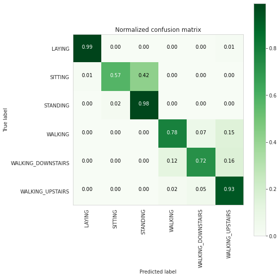

```
No artists with labels found to put in legend.  Note that artists whose label start with an underscore are ignored when legend() is called with no argument.
```

```
-------------------------
| Classifiction Report |
-------------------------
              precision    recall  f1-score   support

           1       0.99      0.99      0.99       422
           2       0.96      0.57      0.72       386
           3       0.71      0.98      0.82       412
           4       0.87      0.78      0.82       368
           5       0.84      0.72      0.78       296
           6       0.74      0.93      0.83       322

    accuracy                           0.83      2206
   macro avg       0.85      0.83      0.83      2206
weighted avg       0.86      0.83      0.83      2206

-------------------------
| ROC Curve |
-------------------------
```

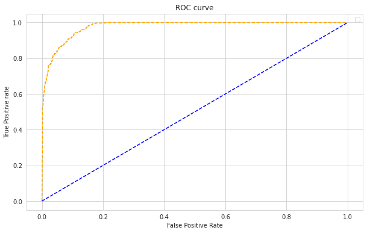

```
--------------------------
|      Best Estimator     |
--------------------------

	GaussianNB(var_smoothing=0.02848035868435802)

--------------------------
|     Best parameters     |
--------------------------
	Parameters of best estimator :

	{'var_smoothing': 0.02848035868435802}

---------------------------------
|   No of CrossValidation sets   |
--------------------------------

	Total number of cross validation sets: 3

--------------------------
|        Best Score       |
--------------------------

	Average Cross Validate scores of best estimator :

	0.8326870408503062
```

```python
# start Grid search with Scaled Data
parameters = {'var_smoothing': np.logspace(0,-9, num=100)}
NB_Gaussian = GaussianNB()
NB_Gaussian_grid = GridSearchCV(NB_Gaussian, param_grid=parameters, cv=3, verbose=1, n_jobs=-1)
NB_Gaussian_grid_results =  perform_model(NB_Gaussian_grid, X_train_scaled, y_train, X_test_scaled, y_test, labels)
# observe the attributes of the model
print_grid_search_attributes(NB_Gaussian_grid_results)
```

## 3. Naive Bayes with BernoulliNB and Grid Search

```
training the model..
Fitting 10 folds for each of 50 candidates, totalling 500 fits
Done


training_time(HH:MM:SS.ms) - 0:00:31.498527


Predicting test data
Done


testing time(HH:MM:SS:ms) - 0:00:00.044973


---------------------
|      Accuracy      |
---------------------

    0.8381686310063463


--------------------
| Confusion Matrix |
--------------------

 [[420   0   0   0   1   1]
 [  0 274 112   0   0   0]
 [  0  87 324   0   0   1]
 [  0   0   0 298  28  42]
 [  0   0   0  21 236  39]
 [  0   0   0  11  14 297]]
```

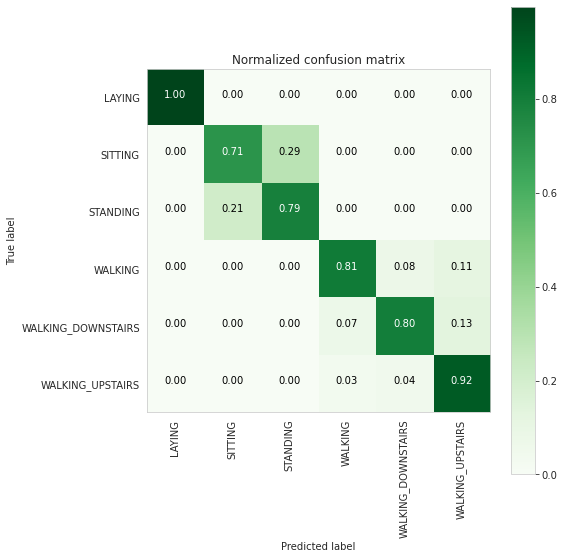

```
No artists with labels found to put in legend.  Note that artists whose label start with an underscore are ignored when legend() is called with no argument.
```

```
-------------------------
| Classifiction Report |
-------------------------
              precision    recall  f1-score   support

           1       1.00      1.00      1.00       422
           2       0.76      0.71      0.73       386
           3       0.74      0.79      0.76       412
           4       0.90      0.81      0.85       368
           5       0.85      0.80      0.82       296
           6       0.78      0.92      0.85       322

    accuracy                           0.84      2206
   macro avg       0.84      0.84      0.84      2206
weighted avg       0.84      0.84      0.84      2206

-------------------------
| ROC Curve |
-------------------------
```

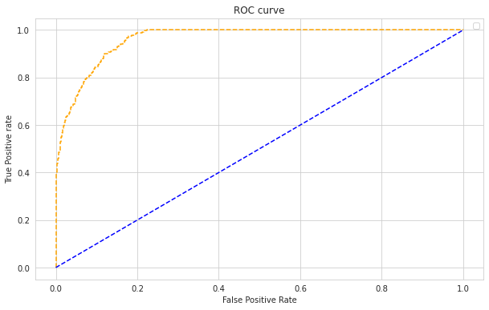

```
--------------------------
|      Best Estimator     |
--------------------------

	BernoulliNB(alpha=0.1, binarize=0.5)

--------------------------
|     Best parameters     |
--------------------------
	Parameters of best estimator :

	{'alpha': 0.1, 'binarize': 0.5, 'class_prior': None, 'fit_prior': True}

---------------------------------
|   No of CrossValidation sets   |
--------------------------------

	Total number of cross validation sets: 10

--------------------------
|        Best Score       |
--------------------------

	Average Cross Validate scores of best estimator :

	0.8375531713951118
```

```python
# start Grid search
parameters = {'alpha':[0.01, 0.1, 0.5, 1.0, 10.0], 'binarize':[0.0, 0.1, 0.5, 1.0, 10.0], 'fit_prior':[True, False], 'class_prior':[None]}
NB_Bernoulli = BernoulliNB()
NB_Bernoulli_grid = GridSearchCV(NB_Bernoulli, param_grid=parameters, cv=10, verbose=1, n_jobs=-1)
NB_Bernoulli_grid_results =  perform_model(NB_Bernoulli_grid, X_train_scaled, y_train, X_test_scaled, y_test, labels)
# observe the attributes of the model
print_grid_search_attributes(NB_Bernoulli_grid_results)
```

## 4. Naive Bayes with CategoricalNB and Grid Search

```
training the model..
Fitting 10 folds for each of 72 candidates, totalling 720 fits
Done


training_time(HH:MM:SS.ms) - 0:03:57.636146


Predicting test data
Done


testing time(HH:MM:SS:ms) - 0:00:00.079955


---------------------
|      Accuracy      |
---------------------

    0.20353581142339075


--------------------
| Confusion Matrix |
--------------------

 [[ 12   3 385   1   0  21]
 [  2   6 362   1   0  15]
 [  1   0 392   1   0  18]
 [  0   0 339   6   0  23]
 [  0   0 252   1  18  25]
 [  0   0 307   0   0  15]]
```

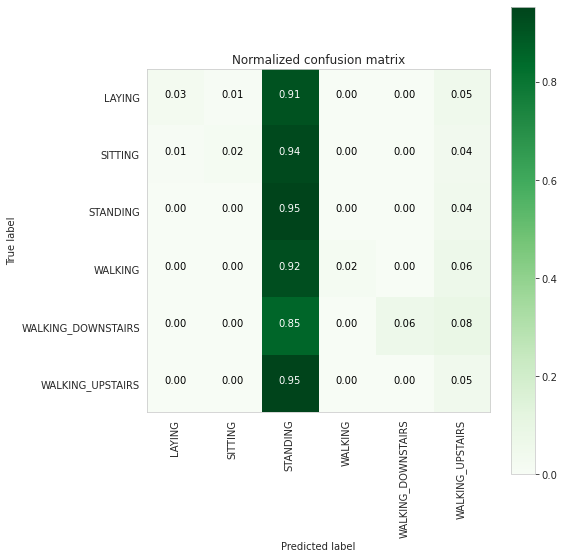

```
No artists with labels found to put in legend.  Note that artists whose label start with an underscore are ignored when legend() is called with no argument.
```

```
-------------------------
| Classifiction Report |
-------------------------
              precision    recall  f1-score   support

           1       0.80      0.03      0.05       422
           2       0.67      0.02      0.03       386
           3       0.19      0.95      0.32       412
           4       0.60      0.02      0.03       368
           5       1.00      0.06      0.11       296
           6       0.13      0.05      0.07       322

    accuracy                           0.20      2206
   macro avg       0.56      0.19      0.10      2206
weighted avg       0.56      0.20      0.11      2206

-------------------------
| ROC Curve |
-------------------------
```

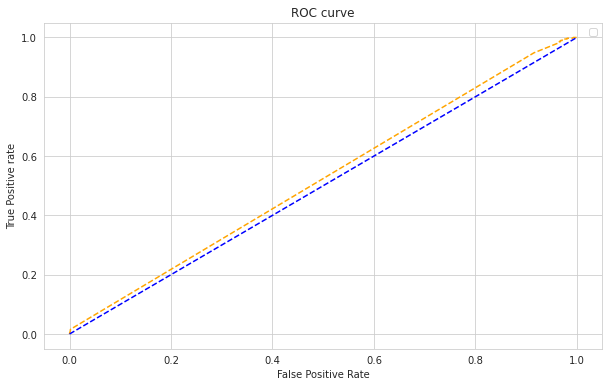

```
--------------------------
|      Best Estimator     |
--------------------------

	CategoricalNB(alpha=0.01, fit_prior=False, min_categories=2)

--------------------------
|     Best parameters     |
--------------------------
	Parameters of best estimator :

	{'alpha': 0.01, 'class_prior': None, 'fit_prior': False, 'min_categories': 2}

---------------------------------
|   No of CrossValidation sets   |
--------------------------------

	Total number of cross validation sets: 10

--------------------------
|        Best Score       |
--------------------------

	Average Cross Validate scores of best estimator :

	0.19218729930867742
```

```python
# start Grid search
parameters = {'alpha':[0.01, 0.1, 0.5, 1.0, 5.0, 10.0], 'min_categories':[1, 2, 3, 4, 5, None], 'fit_prior':[True, False], 'class_prior':[None]}
NB_Categorical = CategoricalNB()
NB_Categorical_grid = GridSearchCV(NB_Categorical, param_grid=parameters, cv=10, verbose=1, n_jobs=-1)
NB_Categorical_grid_results =  perform_model(NB_Categorical_grid, X_train_scaled, y_train, X_test_scaled, y_test, labels)
# observe the attributes of the model
print_grid_search_attributes(NB_Categorical_grid_results)
```

## 5. Naive Bayes with ComplementNB and Grid Search

```
training the model..
Fitting 10 folds for each of 24 candidates, totalling 240 fits
Done


training_time(HH:MM:SS.ms) - 0:00:11.416918


Predicting test data
Done


testing time(HH:MM:SS:ms) - 0:00:00.005999


---------------------
|      Accuracy      |
---------------------

    0.5689029918404351


--------------------
| Confusion Matrix |
--------------------

 [[420   0   0   0   2   0]
 [196   4 186   0   0   0]
 [ 12   0 400   0   0   0]
 [  0   0   0  86 282   0]
 [  0   0   0   0 295   1]
 [  0   0   0   2 270  50]]
```

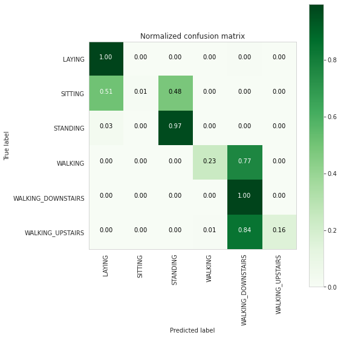

```
No artists with labels found to put in legend.  Note that artists whose label start with an underscore are ignored when legend() is called with no argument.
```

```
-------------------------
| Classifiction Report |
-------------------------
              precision    recall  f1-score   support

           1       0.67      1.00      0.80       422
           2       1.00      0.01      0.02       386
           3       0.68      0.97      0.80       412
           4       0.98      0.23      0.38       368
           5       0.35      1.00      0.52       296
           6       0.98      0.16      0.27       322

    accuracy                           0.57      2206
   macro avg       0.78      0.56      0.46      2206
weighted avg       0.78      0.57      0.48      2206

-------------------------
| ROC Curve |
-------------------------
```

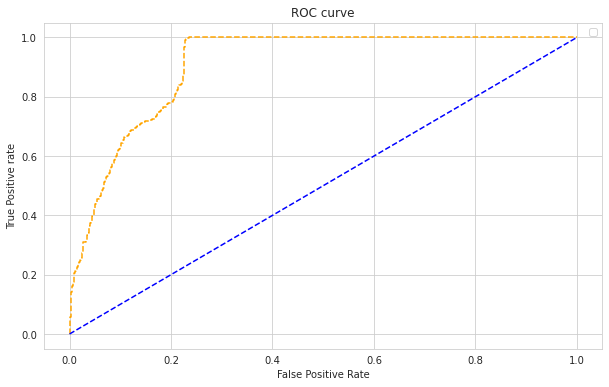

```
--------------------------
|      Best Estimator     |
--------------------------

	ComplementNB(alpha=10.0)

--------------------------
|     Best parameters     |
--------------------------
	Parameters of best estimator :

	{'alpha': 10.0, 'class_prior': None, 'fit_prior': True, 'norm': False}

---------------------------------
|   No of CrossValidation sets   |
--------------------------------

	Total number of cross validation sets: 10

--------------------------
|        Best Score       |
--------------------------

	Average Cross Validate scores of best estimator :

	0.5773382191832571
```

```python
# start Grid search
parameters = {'alpha':[0.01, 0.1, 0.5, 1.0, 5.0, 10.0], 'norm':[True, False], 'fit_prior':[True, False], 'class_prior':[None]}
NB_Complement = ComplementNB()
NB_Complement_grid = GridSearchCV(NB_Complement, param_grid=parameters, cv=10, verbose=1, n_jobs=-1)
NB_Complement_grid_results =  perform_model(NB_Complement_grid, X_train_scaled, y_train, X_test_scaled, y_test, labels)
# observe the attributes of the model
print_grid_search_attributes(NB_Complement_grid_results)
```

## 6. Naive Bayes with MultinomialNB and Grid Search

```
training the model..
Fitting 10 folds for each of 12 candidates, totalling 120 fits
Done


training_time(HH:MM:SS.ms) - 0:00:06.086807


Predicting test data
Done


testing time(HH:MM:SS:ms) - 0:00:00.007998


---------------------
|      Accuracy      |
---------------------

    0.8558476881233001


--------------------
| Confusion Matrix |
--------------------

 [[415   0   0   0   0   7]
 [  5 274 106   0   0   1]
 [  0  49 362   0   0   1]
 [  0   0   0 295  27  46]
 [  0   0   0  16 242  38]
 [  0   0   0   6  16 300]]
```

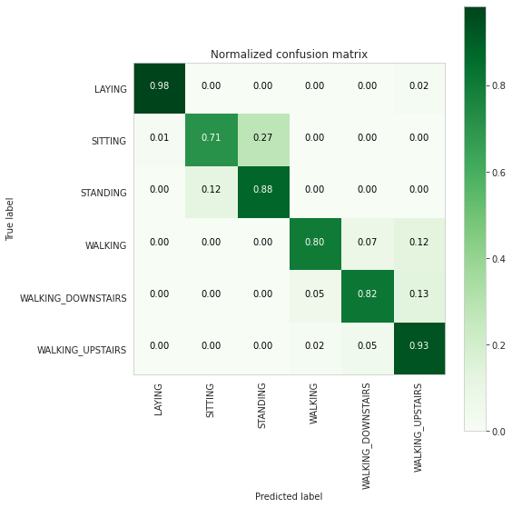

```
No artists with labels found to put in legend.  Note that artists whose label start with an underscore are ignored when legend() is called with no argument.
```

```
-------------------------
| Classifiction Report |
-------------------------
              precision    recall  f1-score   support

           1       0.99      0.98      0.99       422
           2       0.85      0.71      0.77       386
           3       0.77      0.88      0.82       412
           4       0.93      0.80      0.86       368
           5       0.85      0.82      0.83       296
           6       0.76      0.93      0.84       322

    accuracy                           0.86      2206
   macro avg       0.86      0.85      0.85      2206
weighted avg       0.86      0.86      0.86      2206

-------------------------
| ROC Curve |
-------------------------
```

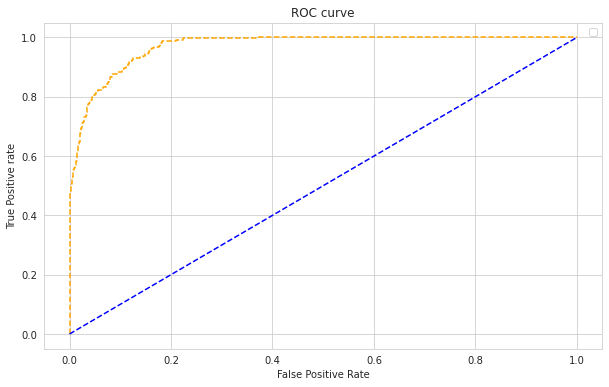

```
--------------------------
|      Best Estimator     |
--------------------------

	MultinomialNB(alpha=10.0, fit_prior=False)

--------------------------
|     Best parameters     |
--------------------------
	Parameters of best estimator :

	{'alpha': 10.0, 'class_prior': None, 'fit_prior': False}

---------------------------------
|   No of CrossValidation sets   |
--------------------------------

	Total number of cross validation sets: 10

--------------------------
|        Best Score       |
--------------------------

	Average Cross Validate scores of best estimator :

	0.84493445657512
```

```python
# start Grid search
parameters = {'alpha':[0.01, 0.1, 0.5, 1.0, 5.0, 10.0], 'fit_prior':[True, False], 'class_prior':[None]}
NB_Multinomial = MultinomialNB()
NB_Multinomial_grid = GridSearchCV(NB_Multinomial, param_grid=parameters, cv=10, verbose=1, n_jobs=-1)
NB_Multinomial_grid_results =  perform_model(NB_Multinomial_grid, X_train_scaled, y_train, X_test_scaled, y_test, labels)
# observe the attributes of the model
print_grid_search_attributes(NB_Multinomial_grid_results)
```

## 7. K-Nearest Neighbours and Grid Search

```
training the model..
Fitting 3 folds for each of 56 candidates, totalling 168 fits
Done


training_time(HH:MM:SS.ms) - 0:05:30.608420


Predicting test data
Done


testing time(HH:MM:SS:ms) - 0:00:02.465188


---------------------
|      Accuracy      |
---------------------

    0.956935630099728


--------------------
| Confusion Matrix |
--------------------

 [[420   1   0   0   0   1]
 [  1 314  71   0   0   0]
 [  0  15 397   0   0   0]
 [  0   0   0 368   0   0]
 [  0   0   0   3 290   3]
 [  0   0   0   0   0 322]]
```

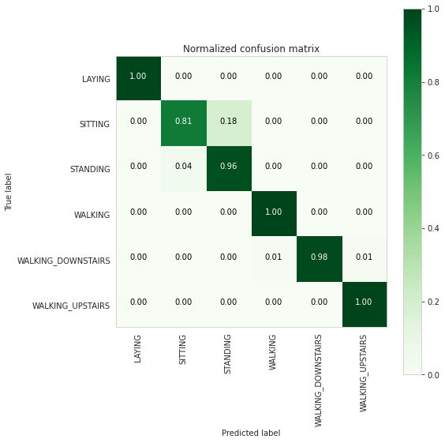

```
-------------------------
| Classifiction Report |
-------------------------
              precision    recall  f1-score   support

           1       1.00      1.00      1.00       422
           2       0.95      0.81      0.88       386
           3       0.85      0.96      0.90       412
           4       0.99      1.00      1.00       368
           5       1.00      0.98      0.99       296
           6       0.99      1.00      0.99       322

    accuracy                           0.96      2206
   macro avg       0.96      0.96      0.96      2206
weighted avg       0.96      0.96      0.96      2206

-------------------------
| ROC Curve |
-------------------------
```

```
No artists with labels found to put in legend.  Note that artists whose label start with an underscore are ignored when legend() is called with no argument.
```

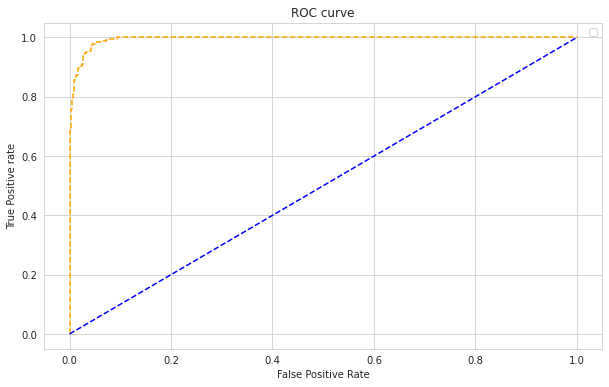

```
--------------------------
|      Best Estimator     |
--------------------------

	KNeighborsClassifier(n_neighbors=15, weights='distance')

--------------------------
|     Best parameters     |
--------------------------
	Parameters of best estimator :

	{'algorithm': 'auto', 'leaf_size': 30, 'metric': 'minkowski', 'n_neighbors': 15, 'p': 2, 'weights': 'distance'}

---------------------------------
|   No of CrossValidation sets   |
--------------------------------

	Total number of cross validation sets: 3

--------------------------
|        Best Score       |
--------------------------

	Average Cross Validate scores of best estimator :

	0.9520009468989062
```

```python
# start Grid search
#parameters = {'n_neighbors':[5.10,15,20,25,30,35,40], 'weights':['uniform', 'distance'], 'algorithm':['auto', 'ball_tree', 'kd_tree', 'brute'], 'leaf_size':[20,30,40], 'p':[1,2,3],
#              'metric':['euclidean', 'manhattan', 'chebyshev','minkowski','wminkowski','seuclidean','mahalanobis']}
parameters = {'n_neighbors':[5.10,15,20,25,30,35,40], 'weights':['uniform', 'distance'], 'algorithm':['auto', 'ball_tree', 'kd_tree', 'brute'], 'leaf_size':[30], 'p':[2],
              'metric':['minkowski']}
K_NN = KNeighborsClassifier()
K_NN_grid = GridSearchCV(K_NN, param_grid=parameters, cv=3, verbose=1, n_jobs=-1)
K_NN_grid_results =  perform_model(K_NN_grid, X_train_scaled, y_train, X_test_scaled, y_test, labels)
# observe the attributes of the model
print_grid_search_attributes(K_NN_grid_results)
```

# Compare time and accuracy of different algos [Marks:1]

```python
for item in Feature_Subset_Result:
    dFFeature_Subset_Result.loc[dFFeature_Subset_Result.shape[0]] = item

print(dFFeature_Subset_Result[['Best Estimator', 'Training Time', 'Testing Time', 'Overall Accuracy of Model',
                                                'Average Cross Validate scores of best estimator']].to_markdown())
```

```
|    | Best Estimator                                               | Training Time          | Testing Time           |   Overall Accuracy of Model |   Average Cross Validate scores of best estimator |
|---:|:-------------------------------------------------------------|:-----------------------|:-----------------------|----------------------------:|--------------------------------------------------:|
|  0 | LogisticRegression(C=10, solver='liblinear')                 | 0 days 00:11:07.399354 | 0 days 00:00:00.008994 |                    0.985494 |                                          0.982705 |
|  1 | GaussianNB(var_smoothing=0.02848035868435802)                | 0 days 00:00:39.714497 | 0 days 00:00:00.160908 |                    0.834995 |                                          0.832687 |
|  2 | BernoulliNB(alpha=0.1, binarize=0.5)                         | 0 days 00:00:31.498527 | 0 days 00:00:00.044973 |                    0.838169 |                                          0.837553 |
|  3 | CategoricalNB(alpha=0.01, fit_prior=False, min_categories=2) | 0 days 00:03:57.636146 | 0 days 00:00:00.079955 |                    0.203536 |                                          0.192187 |
|  4 | ComplementNB(alpha=10.0)                                     | 0 days 00:00:11.416918 | 0 days 00:00:00.005999 |                    0.568903 |                                          0.577338 |
|  5 | MultinomialNB(alpha=10.0, fit_prior=False)                   | 0 days 00:00:06.086807 | 0 days 00:00:00.007998 |                    0.855848 |                                          0.844934 |
|  6 | KNeighborsClassifier(n_neighbors=15, weights='distance')     | 0 days 00:05:30.608420 | 0 days 00:00:02.465188 |                    0.956936 |                                          0.952001 |
```

# Try some feature selection and reduction technique [Marks:2]

**Retrain and Compare time and accuracy of different algos**

## Principal Component Analysis (PCA)

```python
pca = PCA(n_components=0.95, copy=True, whiten=False, svd_solver='auto', tol=0.0, iterated_power='auto', random_state=None)
X_train_scaled_pca = pca.fit_transform(X_train_scaled)
X_test_scaled_pca = pca.transform(X_test_scaled)


print('Shape of original training data: ', X_train_scaled.shape)
print('Shape of pca training data: ', X_train_scaled_pca.shape)

print('\nShape of original testing data: ', X_train_scaled.shape)
print('Shape of pca testing data: ', X_train_scaled_pca.shape)
```

```
Shape of original training data:  (5146, 541)
Shape of pca training data:  (5146, 70)

Shape of original testing data:  (5146, 541)
Shape of pca testing data:  (5146, 70)
```

```python
df_describe = pd.DataFrame(X_train_scaled_pca)
df_describe.describe()
```

|  | 0 | 1 | 2 | 3 | 4 | 5 | 6 | 7 | 8 | 9 | ... | 60 | 61 | 62 | 63 | 64 | 65 | 66 | 67 | 68 | 69 |
| --- | --- | --- | --- | --- | --- | --- | --- | --- | --- | --- | --- | --- | --- | --- | --- | --- | --- | --- | --- | --- | --- |
| count | 5.146000e+03 | 5.146000e+03 | 5.146000e+03 | 5.146000e+03 | 5.146000e+03 | 5.146000e+03 | 5.146000e+03 | 5.146000e+03 | 5.146000e+03 | 5.146000e+03 | ... | 5.146000e+03 | 5.146000e+03 | 5.146000e+03 | 5.146000e+03 | 5.146000e+03 | 5.146000e+03 | 5.146000e+03 | 5.146000e+03 | 5.146000e+03 | 5.146000e+03 |
| mean | -2.675236e-17 | -2.017214e-17 | 3.419556e-17 | 8.662156e-18 | -8.565071e-18 | 1.256714e-18 | 1.353934e-17 | 7.526799e-18 | -5.415196e-18 | 6.966149e-17 | ... | 6.163561e-17 | 3.827718e-17 | 6.359080e-18 | 3.398656e-18 | -2.033395e-18 | -2.275232e-17 | -4.422770e-17 | -7.911094e-18 | -3.136256e-17 | -8.137896e-17 |
| std | 2.882186e+00 | 8.549054e-01 | 7.824853e-01 | 5.258867e-01 | 4.872523e-01 | 4.270208e-01 | 4.124831e-01 | 3.959599e-01 | 3.806996e-01 | 3.503779e-01 | ... | 1.276845e-01 | 1.262297e-01 | 1.248971e-01 | 1.228045e-01 | 1.220367e-01 | 1.208179e-01 | 1.202106e-01 | 1.186396e-01 | 1.164433e-01 | 1.143961e-01 |
| min | -3.272187e+00 | -2.470350e+00 | -1.429112e+00 | -1.355810e+00 | -2.133329e+00 | -1.124994e+00 | -1.203674e+00 | -1.331405e+00 | -1.133338e+00 | -1.101829e+00 | ... | -4.288903e-01 | -5.180213e-01 | -5.108712e-01 | -5.083904e-01 | -4.522399e-01 | -7.530619e-01 | -4.846505e-01 | -6.568222e-01 | -4.926998e-01 | -6.468781e-01 |
| 25% | -2.707702e+00 | -6.115480e-01 | -5.646930e-01 | -3.491131e-01 | -2.884221e-01 | -2.986830e-01 | -2.853230e-01 | -2.879488e-01 | -2.591389e-01 | -2.404865e-01 | ... | -8.471176e-02 | -8.360035e-02 | -7.920228e-02 | -7.705237e-02 | -8.175087e-02 | -7.606031e-02 | -7.879097e-02 | -7.460045e-02 | -7.506087e-02 | -7.092540e-02 |
| 50% | -1.611345e+00 | 2.505290e-02 | -8.694892e-02 | -2.466041e-03 | 2.161067e-02 | -5.081949e-02 | -4.652364e-03 | -3.372633e-02 | -2.489598e-02 | -1.760168e-02 | ... | -2.612677e-03 | -6.146119e-04 | -6.617734e-04 | 3.076621e-03 | -2.931232e-03 | 5.835245e-06 | -1.064237e-03 | 1.355427e-04 | -1.785264e-03 | -8.059321e-04 |
| 75% | 2.760519e+00 | 5.801697e-01 | 3.291250e-01 | 2.934889e-01 | 3.074530e-01 | 2.556413e-01 | 2.808159e-01 | 2.756069e-01 | 2.562314e-01 | 2.220249e-01 | ... | 8.271020e-02 | 8.285988e-02 | 8.243856e-02 | 7.938036e-02 | 8.088131e-02 | 7.525347e-02 | 7.671190e-02 | 7.302209e-02 | 7.654528e-02 | 6.818514e-02 |
| max | 9.359781e+00 | 4.478655e+00 | 3.016690e+00 | 3.393210e+00 | 2.183239e+00 | 2.191070e+00 | 1.483489e+00 | 1.336413e+00 | 1.905951e+00 | 1.516618e+00 | ... | 6.119887e-01 | 5.468155e-01 | 7.910961e-01 | 1.034394e+00 | 5.438993e-01 | 8.022790e-01 | 6.501323e-01 | 7.053312e-01 | 5.745490e-01 | 8.453404e-01 |

8 rows × 70 columns

#### Understand variance caused by each of the principal components

The PCA class contains explained_variance*ratio* which returns the variance caused by each of the principal components. Execute the following line of code to find the "explained variance ratio".

The explained_variance variable is now a float type array which contains variance ratios for each principal component. The values for the explained_variance variable looks like this:

```python
pca.explained_variance_ratio_
```

```
array([0.59807887, 0.05261997, 0.04408257, 0.01991127, 0.01709316,
       0.01312842, 0.01224974, 0.011288  , 0.01043469, 0.00883869,
       0.00881122, 0.00761672, 0.00696069, 0.00628526, 0.005701  ,
       0.00520655, 0.0050607 , 0.00472644, 0.00449395, 0.00443351,
       0.00405793, 0.00399408, 0.00396643, 0.0036298 , 0.00356017,
       0.00348959, 0.003311  , 0.0032549 , 0.0031977 , 0.00306735,
       0.00301714, 0.0028358 , 0.00273932, 0.00254493, 0.0025062 ,
       0.00242908, 0.00230197, 0.00223544, 0.00218209, 0.00217153,
       0.00212932, 0.00202016, 0.00193076, 0.00185598, 0.00184267,
       0.00181309, 0.00179548, 0.00169565, 0.00164949, 0.00160241,
       0.00157324, 0.00151736, 0.00144745, 0.00142012, 0.00139556,
       0.00136857, 0.00129878, 0.00126888, 0.00123853, 0.00120691,
       0.00117379, 0.0011472 , 0.0011231 , 0.00108578, 0.00107225,
       0.00105094, 0.0010404 , 0.00101338, 0.00097621, 0.00094219])
```

## 8. Logistic Regression with Grid Search and PCA

```
training the model..
Fitting 3 folds for each of 60 candidates, totalling 180 fits
Done


training_time(HH:MM:SS.ms) - 0:02:49.663472


Predicting test data
Done


testing time(HH:MM:SS:ms) - 0:00:00.000999


---------------------
|      Accuracy      |
---------------------

    0.971441523118767


--------------------
| Confusion Matrix |
--------------------

 [[422   0   0   0   0   0]
 [  0 353  33   0   0   0]
 [  0  24 388   0   0   0]
 [  0   0   0 367   1   0]
 [  0   0   0   0 294   2]
 [  0   0   0   3   0 319]]
```

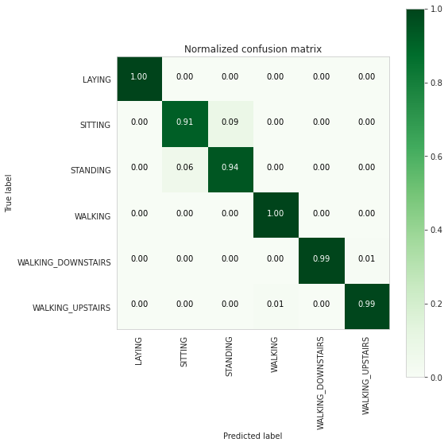

```
No artists with labels found to put in legend.  Note that artists whose label start with an underscore are ignored when legend() is called with no argument.
```

```
-------------------------
| Classifiction Report |
-------------------------
              precision    recall  f1-score   support

           1       1.00      1.00      1.00       422
           2       0.94      0.91      0.93       386
           3       0.92      0.94      0.93       412
           4       0.99      1.00      0.99       368
           5       1.00      0.99      0.99       296
           6       0.99      0.99      0.99       322

    accuracy                           0.97      2206
   macro avg       0.97      0.97      0.97      2206
weighted avg       0.97      0.97      0.97      2206

-------------------------
| ROC Curve |
-------------------------
```

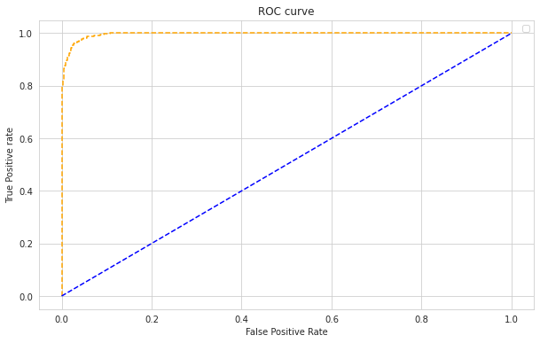

```
--------------------------
|      Best Estimator     |
--------------------------

	LogisticRegression(C=10, penalty='l1', solver='saga')

--------------------------
|     Best parameters     |
--------------------------
	Parameters of best estimator :

	{'C': 10, 'penalty': 'l1', 'solver': 'saga'}

---------------------------------
|   No of CrossValidation sets   |
--------------------------------

	Total number of cross validation sets: 3

--------------------------
|        Best Score       |
--------------------------

	Average Cross Validate scores of best estimator :

	0.9657981474308005
```

```python
# start Grid search with scaled data
parameters = {'C':[0.01, 0.1, 1, 10, 20, 30], 'penalty':['l2','l1'], 'solver':['newton-cg', 'lbfgs', 'liblinear', 'sag', 'saga']}
#parameters = {'C':[0.01, 0.1, 1, 10, 20, 30], 'penalty':['l2','l1','elasticnet','none'], 'dual':[True,False], 'tol':[1e-4], 'fit_intercept':[True,False], 'intercept_scaling':[1,2,5,10],
#              'class_weight':[None,'balanced'], 'solver':['newton-cg', 'lbfgs', 'liblinear', 'sag', 'saga'], 'max_iter':[1000]}
log_reg_pca = linear_model.LogisticRegression()
log_reg_grid_pca = GridSearchCV(log_reg_pca, param_grid=parameters, cv=3, verbose=1, n_jobs=-1)
log_reg_grid_results_pca =  perform_model(log_reg_grid_pca, X_train_scaled_pca, y_train, X_test_scaled_pca, y_test, labels)
# observe the attributes of the model
print_grid_search_attributes(log_reg_grid_results_pca)
```

## 9. Naive Bayes with GaussianNB, Grid Search and PCA

```
training the model..
Fitting 3 folds for each of 100 candidates, totalling 300 fits
Done


training_time(HH:MM:SS.ms) - 0:00:06.350876


Predicting test data
Done


testing time(HH:MM:SS:ms) - 0:00:00.028995


---------------------
|      Accuracy      |
---------------------

    0.9075249320036265


--------------------
| Confusion Matrix |
--------------------

 [[422   0   0   0   0   0]
 [  5 272 106   0   3   0]
 [  5  26 380   1   0   0]
 [  0   0   0 343  12  13]
 [  0   0   0   3 272  21]
 [  0   0   0   6   3 313]]
```

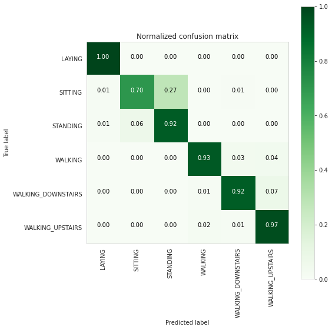

```
No artists with labels found to put in legend.  Note that artists whose label start with an underscore are ignored when legend() is called with no argument.
```

```
-------------------------
| Classifiction Report |
-------------------------
              precision    recall  f1-score   support

           1       0.98      1.00      0.99       422
           2       0.91      0.70      0.80       386
           3       0.78      0.92      0.85       412
           4       0.97      0.93      0.95       368
           5       0.94      0.92      0.93       296
           6       0.90      0.97      0.94       322

    accuracy                           0.91      2206
   macro avg       0.91      0.91      0.91      2206
weighted avg       0.91      0.91      0.91      2206

-------------------------
| ROC Curve |
-------------------------
```

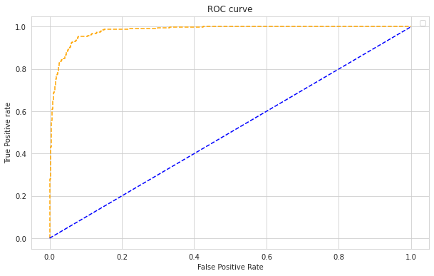

```
--------------------------
|      Best Estimator     |
--------------------------

	GaussianNB(var_smoothing=0.0002848035868435802)

--------------------------
|     Best parameters     |
--------------------------
	Parameters of best estimator :

	{'var_smoothing': 0.0002848035868435802}

---------------------------------
|   No of CrossValidation sets   |
--------------------------------

	Total number of cross validation sets: 3

--------------------------
|        Best Score       |
--------------------------

	Average Cross Validate scores of best estimator :

	0.8975901649371036
```

```python
# start Grid search with Scaled Data
parameters = {'var_smoothing': np.logspace(0,-9, num=100)}
NB_Gaussian_pca = GaussianNB()
NB_Gaussian_grid_pca = GridSearchCV(NB_Gaussian_pca, param_grid=parameters, cv=3, verbose=1, n_jobs=-1)
NB_Gaussian_grid_results_pca =  perform_model(NB_Gaussian_grid_pca, X_train_scaled_pca, y_train, X_test_scaled_pca, y_test, labels)
# observe the attributes of the model
print_grid_search_attributes(NB_Gaussian_grid_results_pca)
```

## 10. Naive Bayes with BernoulliNB, Grid Search and PCA

```
training the model..
Fitting 3 folds for each of 50 candidates, totalling 150 fits
Done


training_time(HH:MM:SS.ms) - 0:00:02.165755


Predicting test data
Done


testing time(HH:MM:SS:ms) - 0:00:00.012993


---------------------
|      Accuracy      |
---------------------

    0.8766999093381687


--------------------
| Confusion Matrix |
--------------------

 [[404  14   0   0   4   0]
 [  9 296  81   0   0   0]
 [  1  65 346   0   0   0]
 [  0   0   0 337  17  14]
 [  0   0   0  13 258  25]
 [  0   0   0  16  13 293]]
```

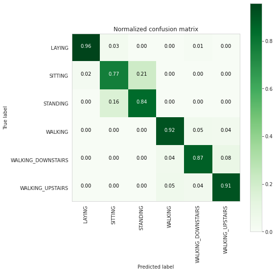

```
No artists with labels found to put in legend.  Note that artists whose label start with an underscore are ignored when legend() is called with no argument.
```

```
-------------------------
| Classifiction Report |
-------------------------
              precision    recall  f1-score   support

           1       0.98      0.96      0.97       422
           2       0.79      0.77      0.78       386
           3       0.81      0.84      0.82       412
           4       0.92      0.92      0.92       368
           5       0.88      0.87      0.88       296
           6       0.88      0.91      0.90       322

    accuracy                           0.88      2206
   macro avg       0.88      0.88      0.88      2206
weighted avg       0.88      0.88      0.88      2206

-------------------------
| ROC Curve |
-------------------------
```

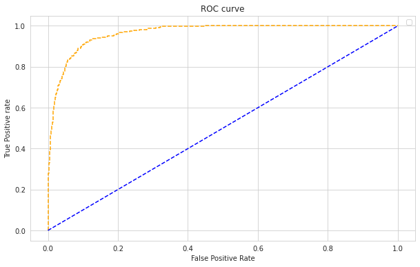

```
--------------------------
|      Best Estimator     |
--------------------------

	BernoulliNB(fit_prior=False)

--------------------------
|     Best parameters     |
--------------------------
	Parameters of best estimator :

	{'alpha': 1.0, 'binarize': 0.0, 'class_prior': None, 'fit_prior': False}

---------------------------------
|   No of CrossValidation sets   |
--------------------------------

	Total number of cross validation sets: 3

--------------------------
|        Best Score       |
--------------------------

	Average Cross Validate scores of best estimator :

	0.8668879872961505
```

```python
# start Grid search
parameters = {'alpha':[0.01, 0.1, 0.5, 1.0, 10.0], 'binarize':[0.0, 0.1, 0.5, 1.0, 10.0], 'fit_prior':[True, False], 'class_prior':[None]}
NB_Bernoulli_pca = BernoulliNB()
NB_Bernoulli_grid_pca = GridSearchCV(NB_Bernoulli_pca, param_grid=parameters, cv=3, verbose=1, n_jobs=-1)
NB_Bernoulli_grid_results_pca =  perform_model(NB_Bernoulli_grid_pca, X_train_scaled_pca, y_train, X_test_scaled_pca, y_test, labels)
# observe the attributes of the model
print_grid_search_attributes(NB_Bernoulli_grid_results_pca)
```

### CategoricalNB, ComplementNB, MultinomialNB will not work for PCA generated X data as it has negative values

## 11. K-Nearest Neighbours, Grid Search and PCA

```
training the model..
Fitting 3 folds for each of 56 candidates, totalling 168 fits
Done


training_time(HH:MM:SS.ms) - 0:00:53.464397


Predicting test data
Done


testing time(HH:MM:SS:ms) - 0:00:00.654623


---------------------
|      Accuracy      |
---------------------

    0.9533091568449683


--------------------
| Confusion Matrix |
--------------------

 [[420   1   0   0   1   0]
 [  1 315  70   0   0   0]
 [  0  22 390   0   0   0]
 [  0   0   0 367   1   0]
 [  0   0   0   3 289   4]
 [  0   0   0   0   0 322]]
```

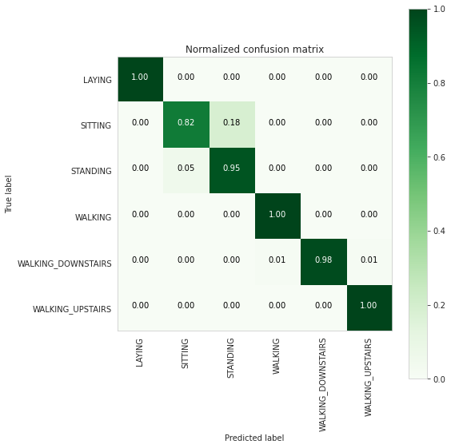

```
-------------------------
| Classifiction Report |
-------------------------
              precision    recall  f1-score   support

           1       1.00      1.00      1.00       422
           2       0.93      0.82      0.87       386
           3       0.85      0.95      0.89       412
           4       0.99      1.00      0.99       368
           5       0.99      0.98      0.98       296
           6       0.99      1.00      0.99       322

    accuracy                           0.95      2206
   macro avg       0.96      0.96      0.96      2206
weighted avg       0.96      0.95      0.95      2206

-------------------------
| ROC Curve |
-------------------------
```

```
No artists with labels found to put in legend.  Note that artists whose label start with an underscore are ignored when legend() is called with no argument.
```

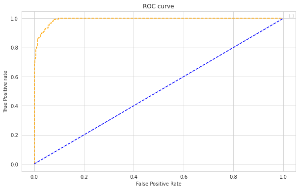

```
--------------------------
|      Best Estimator     |
--------------------------

	KNeighborsClassifier(n_neighbors=15, weights='distance')

--------------------------
|     Best parameters     |
--------------------------
	Parameters of best estimator :

	{'algorithm': 'auto', 'leaf_size': 30, 'metric': 'minkowski', 'n_neighbors': 15, 'p': 2, 'weights': 'distance'}

---------------------------------
|   No of CrossValidation sets   |
--------------------------------

	Total number of cross validation sets: 3

--------------------------
|        Best Score       |
--------------------------

	Average Cross Validate scores of best estimator :

	0.9477252905824334
```

```python
# start Grid search
#parameters = {'n_neighbors':[5.10,15,20,25,30,35,40], 'weights':['uniform', 'distance'], 'algorithm':['auto', 'ball_tree', 'kd_tree', 'brute'], 'leaf_size':[20,30,40], 'p':[1,2,3],
#              'metric':['euclidean', 'manhattan', 'chebyshev','minkowski','wminkowski','seuclidean','mahalanobis']}
parameters = {'n_neighbors':[5.10,15,20,25,30,35,40], 'weights':['uniform', 'distance'], 'algorithm':['auto', 'ball_tree', 'kd_tree', 'brute'], 'leaf_size':[30], 'p':[2],
              'metric':['minkowski']}
K_NN_pca = KNeighborsClassifier()
K_NN_grid_pca = GridSearchCV(K_NN_pca, param_grid=parameters, cv=3, verbose=1, n_jobs=-1)
K_NN_grid_results_pca =  perform_model(K_NN_grid_pca, X_train_scaled_pca, y_train, X_test_scaled_pca, y_test, labels)
# observe the attributes of the model
print_grid_search_attributes(K_NN_grid_results_pca)
```

# Compare time and accuracy of different algorithms

```python
dFFeature_Subset_Result.drop(dFFeature_Subset_Result.index, inplace=True)

for item in Feature_Subset_Result:
    dFFeature_Subset_Result.loc[dFFeature_Subset_Result.shape[0]] = item

print(dFFeature_Subset_Result[['Best Estimator', 'Training Time', 'Testing Time', 'Overall Accuracy of Model',
                                                'Average Cross Validate scores of best estimator']].to_markdown())
```

```
|    | Best Estimator                                               | Training Time          | Testing Time           |   Overall Accuracy of Model |   Average Cross Validate scores of best estimator |
|---:|:-------------------------------------------------------------|:-----------------------|:-----------------------|----------------------------:|--------------------------------------------------:|
|  0 | LogisticRegression(C=10, solver='liblinear')                 | 0 days 00:11:07.399354 | 0 days 00:00:00.008994 |                    0.985494 |                                          0.982705 |
|  1 | GaussianNB(var_smoothing=0.02848035868435802)                | 0 days 00:00:39.714497 | 0 days 00:00:00.160908 |                    0.834995 |                                          0.832687 |
|  2 | BernoulliNB(alpha=0.1, binarize=0.5)                         | 0 days 00:00:31.498527 | 0 days 00:00:00.044973 |                    0.838169 |                                          0.837553 |
|  3 | CategoricalNB(alpha=0.01, fit_prior=False, min_categories=2) | 0 days 00:03:57.636146 | 0 days 00:00:00.079955 |                    0.203536 |                                          0.192187 |
|  4 | ComplementNB(alpha=10.0)                                     | 0 days 00:00:11.416918 | 0 days 00:00:00.005999 |                    0.568903 |                                          0.577338 |
|  5 | MultinomialNB(alpha=10.0, fit_prior=False)                   | 0 days 00:00:06.086807 | 0 days 00:00:00.007998 |                    0.855848 |                                          0.844934 |
|  6 | KNeighborsClassifier(n_neighbors=15, weights='distance')     | 0 days 00:05:30.608420 | 0 days 00:00:02.465188 |                    0.956936 |                                          0.952001 |
|  7 | LogisticRegression(C=10, penalty='l1', solver='saga')        | 0 days 00:02:49.663472 | 0 days 00:00:00.000999 |                    0.971442 |                                          0.965798 |
|  8 | GaussianNB(var_smoothing=0.0002848035868435802)              | 0 days 00:00:06.350876 | 0 days 00:00:00.028995 |                    0.907525 |                                          0.89759  |
|  9 | BernoulliNB(fit_prior=False)                                 | 0 days 00:00:02.165755 | 0 days 00:00:00.012993 |                    0.8767   |                                          0.866888 |
| 10 | KNeighborsClassifier(n_neighbors=15, weights='distance')     | 0 days 00:00:53.464397 | 0 days 00:00:00.654623 |                    0.953309 |                                          0.947725 |
```

### Basis this the model with the best accuracy level is '0' i.e. LogisticRegression(C=10) without PCA

## Feature Selection with Forward Subset Selection Algorithm

```python
# Sequential Forward Selection(sfs)
sfs = SFS(LinearRegression(),
          k_features=20,
          forward=True,
          floating=False,
          scoring = 'r2',
          cv = 0)
NewList = list(inputData1)
NewList = NewList[:-1]
feature_names = NewList
sfs.fit(X,y, custom_feature_names=feature_names)
sfs.k_feature_names_     # to get the final set of features
```

```
('tBodyAcc-std()-X',
 'tBodyAcc-mad()-X',
 'tBodyAcc-max()-X',
 'tGravityAcc-std()-X',
 'tGravityAcc-max()-Y',
 'tGravityAcc-sma()',
 'tGravityAcc-energy()-Z',
 'tBodyAccJerk-correlation()-X,Y',
 'tBodyAccMag-mad()',
 'tBodyAccJerkMag-mad()',
 'fBodyAcc-max()-X',
 'fBodyAcc-bandsEnergy()-1,8.1',
 'fBodyAcc-bandsEnergy()-1,16.2',
 'fBodyAccJerk-std()-X',
 'fBodyAccJerk-entropy()-X',
 'fBodyAccJerk-bandsEnergy()-1,8',
 'fBodyAccJerk-bandsEnergy()-17,32',
 'fBodyAccJerk-bandsEnergy()-17,32.1',
 'fBodyGyro-meanFreq()-X',
 'fBodyGyro-bandsEnergy()-1,8.1')
```

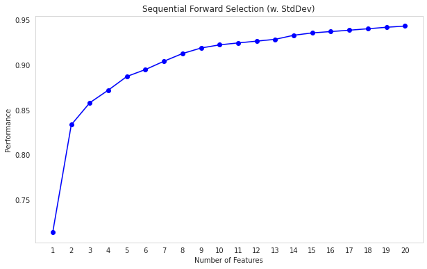

```python
fig1 = plot_sfs(sfs.get_metric_dict(), kind='std_dev')
#plt.ylim([0.8, 1])
plt.title('Sequential Forward Selection (w. StdDev)')
plt.grid()
plt.show()
```

```python
pd.DataFrame.from_dict(sfs.get_metric_dict()).T
```

|  | feature_idx | cv_scores | avg_score | feature_names | ci_bound | std_dev | std_err |
| --- | --- | --- | --- | --- | --- | --- | --- |
| 1 | (349,) | [0.7143462627456874] | 0.714346 | (fBodyAccJerk-entropy()-X,) | NaN | 0.0 | NaN |
| 2 | (50, 349) | [0.8334844015774368] | 0.833484 | (tGravityAcc-max()-Y, fBodyAccJerk-entropy()-X) | NaN | 0.0 | NaN |
| 3 | (50, 349, 387) | [0.8579201926203095] | 0.85792 | (tGravityAcc-max()-Y, fBodyAccJerk-entropy()-X, fBodyAccJerk-bandsEnergy()-17,32.1) | NaN | 0.0 | NaN |
| 4 | (50, 58, 349, 387) | [0.8719514989226493] | 0.871951 | (tGravityAcc-max()-Y, tGravityAcc-energy()-Z, fBodyAccJerk-entropy()-X, fBodyAccJerk-bandsEnergy()-17,32.1) | NaN | 0.0 | NaN |
| 5 | (50, 58, 299, 349, 387) | [0.8870744437557582] | 0.887074 | (tGravityAcc-max()-Y, tGravityAcc-energy()-Z, fBodyAcc-bandsEnergy()-1,8.1, fBodyAccJerk-entropy()-X, fBodyAccJerk-bandsEnergy()-17,32.1) | NaN | 0.0 | NaN |
| 6 | (50, 58, 257, 299, 349, 387) | [0.8947355486163908] | 0.894736 | (tGravityAcc-max()-Y, tGravityAcc-energy()-Z, fBodyAcc-max()-X, fBodyAcc-bandsEnergy()-1,8.1, fBodyAccJerk-entropy()-X, fBodyAccJerk-bandsEnergy()-17,32.1) | NaN | 0.0 | NaN |
| 7 | (50, 58, 214, 257, 299, 349, 387) | [0.9039694019119356] | 0.903969 | (tGravityAcc-max()-Y, tGravityAcc-energy()-Z, tBodyAccJerkMag-mad(), fBodyAcc-max()-X, fBodyAcc-bandsEnergy()-1,8.1, fBodyAccJerk-entropy()-X, fBodyAccJerk-bandsEnergy()-17,32.1) | NaN | 0.0 | NaN |
| 8 | (50, 58, 214, 257, 299, 321, 349, 387) | [0.9124895701377869] | 0.91249 | (tGravityAcc-max()-Y, tGravityAcc-energy()-Z, tBodyAccJerkMag-mad(), fBodyAcc-max()-X, fBodyAcc-bandsEnergy()-1,8.1, fBodyAcc-bandsEnergy()-1,16.2, fBodyAccJerk-entropy()-X, fBodyAccJerk-bandsEnergy()… | NaN | 0.0 | NaN |
| 9 | (9, 50, 58, 214, 257, 299, 321, 349, 387) | [0.918617061221606] | 0.918617 | (tBodyAcc-max()-X, tGravityAcc-max()-Y, tGravityAcc-energy()-Z, tBodyAccJerkMag-mad(), fBodyAcc-max()-X, fBodyAcc-bandsEnergy()-1,8.1, fBodyAcc-bandsEnergy()-1,16.2, fBodyAccJerk-entropy()-X, fBodyAcc… | NaN | 0.0 | NaN |
| 10 | (9, 50, 55, 58, 214, 257, 299, 321, 349, 387) | [0.9221282071056801] | 0.922128 | (tBodyAcc-max()-X, tGravityAcc-max()-Y, tGravityAcc-sma(), tGravityAcc-energy()-Z, tBodyAccJerkMag-mad(), fBodyAcc-max()-X, fBodyAcc-bandsEnergy()-1,8.1, fBodyAcc-bandsEnergy()-1,16.2, fBodyAccJerk-en… | NaN | 0.0 | NaN |
| 11 | (9, 43, 50, 55, 58, 214, 257, 299, 321, 349, 387) | [0.9242530145582166] | 0.924253 | (tBodyAcc-max()-X, tGravityAcc-std()-X, tGravityAcc-max()-Y, tGravityAcc-sma(), tGravityAcc-energy()-Z, tBodyAccJerkMag-mad(), fBodyAcc-max()-X, fBodyAcc-bandsEnergy()-1,8.1, fBodyAcc-bandsEnergy()-1,… | NaN | 0.0 | NaN |
| 12 | (9, 43, 50, 55, 58, 117, 214, 257, 299, 321, 349, 387) | [0.9262684766786048] | 0.926268 | (tBodyAcc-max()-X, tGravityAcc-std()-X, tGravityAcc-max()-Y, tGravityAcc-sma(), tGravityAcc-energy()-Z, tBodyAccJerk-correlation()-X,Y, tBodyAccJerkMag-mad(), fBodyAcc-max()-X, fBodyAcc-bandsEnergy()-… | NaN | 0.0 | NaN |
| 13 | (3, 9, 43, 50, 55, 58, 117, 214, 257, 299, 321, 349, 387) | [0.9282477367752042] | 0.928248 | (tBodyAcc-std()-X, tBodyAcc-max()-X, tGravityAcc-std()-X, tGravityAcc-max()-Y, tGravityAcc-sma(), tGravityAcc-energy()-Z, tBodyAccJerk-correlation()-X,Y, tBodyAccJerkMag-mad(), fBodyAcc-max()-X, fBody… | NaN | 0.0 | NaN |
| 14 | (3, 9, 43, 50, 55, 58, 117, 214, 257, 299, 321, 349, 364, 387) | [0.9327492111129564] | 0.932749 | (tBodyAcc-std()-X, tBodyAcc-max()-X, tGravityAcc-std()-X, tGravityAcc-max()-Y, tGravityAcc-sma(), tGravityAcc-energy()-Z, tBodyAccJerk-correlation()-X,Y, tBodyAccJerkMag-mad(), fBodyAcc-max()-X, fBody… | NaN | 0.0 | NaN |
| 15 | (3, 6, 9, 43, 50, 55, 58, 117, 214, 257, 299, 321, 349, 364, 387) | [0.935388937263161] | 0.935389 | (tBodyAcc-std()-X, tBodyAcc-mad()-X, tBodyAcc-max()-X, tGravityAcc-std()-X, tGravityAcc-max()-Y, tGravityAcc-sma(), tGravityAcc-energy()-Z, tBodyAccJerk-correlation()-X,Y, tBodyAccJerkMag-mad(), fBody… | NaN | 0.0 | NaN |
| 16 | (3, 6, 9, 43, 50, 55, 58, 117, 214, 257, 299, 321, 349, 364, 387, 434) | [0.9368639177633373] | 0.936864 | (tBodyAcc-std()-X, tBodyAcc-mad()-X, tBodyAcc-max()-X, tGravityAcc-std()-X, tGravityAcc-max()-Y, tGravityAcc-sma(), tGravityAcc-energy()-Z, tBodyAccJerk-correlation()-X,Y, tBodyAccJerkMag-mad(), fBody… | NaN | 0.0 | NaN |
| 17 | (3, 6, 9, 43, 50, 55, 58, 117, 202, 214, 257, 299, 321, 349, 364, 387, 434) | [0.9383652418173041] | 0.938365 | (tBodyAcc-std()-X, tBodyAcc-mad()-X, tBodyAcc-max()-X, tGravityAcc-std()-X, tGravityAcc-max()-Y, tGravityAcc-sma(), tGravityAcc-energy()-Z, tBodyAccJerk-correlation()-X,Y, tBodyAccMag-mad(), tBodyAccJ… | NaN | 0.0 | NaN |
| 18 | (3, 6, 9, 43, 50, 55, 58, 117, 202, 214, 257, 299, 321, 330, 349, 364, 387, 434) | [0.9399798555782127] | 0.93998 | (tBodyAcc-std()-X, tBodyAcc-mad()-X, tBodyAcc-max()-X, tGravityAcc-std()-X, tGravityAcc-max()-Y, tGravityAcc-sma(), tGravityAcc-energy()-Z, tBodyAccJerk-correlation()-X,Y, tBodyAccMag-mad(), tBodyAccJ… | NaN | 0.0 | NaN |
| 19 | (3, 6, 9, 43, 50, 55, 58, 117, 202, 214, 257, 299, 321, 330, 349, 364, 373, 387, 434) | [0.9416154150892353] | 0.941615 | (tBodyAcc-std()-X, tBodyAcc-mad()-X, tBodyAcc-max()-X, tGravityAcc-std()-X, tGravityAcc-max()-Y, tGravityAcc-sma(), tGravityAcc-energy()-Z, tBodyAccJerk-correlation()-X,Y, tBodyAccMag-mad(), tBodyAccJ… | NaN | 0.0 | NaN |
| 20 | (3, 6, 9, 43, 50, 55, 58, 117, 202, 214, 257, 299, 321, 330, 349, 364, 373, 387, 434, 457) | [0.9429621550728244] | 0.942962 | (tBodyAcc-std()-X, tBodyAcc-mad()-X, tBodyAcc-max()-X, tGravityAcc-std()-X, tGravityAcc-max()-Y, tGravityAcc-sma(), tGravityAcc-energy()-Z, tBodyAccJerk-correlation()-X,Y, tBodyAccMag-mad(), tBodyAccJ… | NaN | 0.0 | NaN |

### Prepare Train and Test Data basis Feature Subset Selected

```python
#type(X_train_scaled)
X_train_scaled_ffs = pd.DataFrame(X_train_scaled, columns=NewList)
X_train_scaled_ffs.drop(X_train_scaled_ffs.columns.difference(sfs.k_feature_names_), 1, inplace=True)
X_train_scaled_ffs

X_test_scaled_ffs = pd.DataFrame(X_test_scaled, columns=NewList)
X_test_scaled_ffs.drop(X_test_scaled_ffs.columns.difference(sfs.k_feature_names_), 1, inplace=True)
X_test_scaled_ffs
```

|  | tBodyAcc-std()-X | tBodyAcc-mad()-X | tBodyAcc-max()-X | tGravityAcc-std()-X | tGravityAcc-max()-Y | tGravityAcc-sma() | tGravityAcc-energy()-Z | tBodyAccJerk-correlation()-X,Y | tBodyAccMag-mad() | tBodyAccJerkMag-mad() | fBodyAcc-max()-X | fBodyAcc-bandsEnergy()-1,8.1 | fBodyAcc-bandsEnergy()-1,16.2 | fBodyAccJerk-std()-X | fBodyAccJerk-entropy()-X | fBodyAccJerk-bandsEnergy()-1,8 | fBodyAccJerk-bandsEnergy()-17,32 | fBodyAccJerk-bandsEnergy()-17,32.1 | fBodyGyro-meanFreq()-X | fBodyGyro-bandsEnergy()-1,8.1 |
| --- | --- | --- | --- | --- | --- | --- | --- | --- | --- | --- | --- | --- | --- | --- | --- | --- | --- | --- | --- | --- |
| 0 | 0.003800 | 0.003197 | 0.028979 | 0.010430 | 0.844038 | 0.762383 | 0.361209 | 0.497790 | 0.004984 | 0.002280 | 0.003334 | 0.000111 | 0.000146 | 0.002886 | 0.000000 | 0.000006 | 0.000053 | 0.000057 | 0.577001 | 0.000064 |
| 1 | 0.390580 | 0.342019 | 0.436767 | 0.013416 | 0.085289 | 0.567166 | 0.013594 | 0.263295 | 0.377761 | 0.290662 | 0.374737 | 0.302258 | 0.140412 | 0.279892 | 0.744032 | 0.103365 | 0.081708 | 0.179697 | 0.462833 | 0.048006 |
| 2 | 0.002141 | 0.001630 | 0.034629 | 0.001539 | 0.436209 | 0.522628 | 0.055630 | 0.539149 | 0.002855 | 0.002825 | 0.002430 | 0.000156 | 0.000151 | 0.001686 | 0.000000 | 0.000008 | 0.000030 | 0.000099 | 0.483978 | 0.000092 |
| 3 | 0.012496 | 0.012082 | 0.041154 | 0.014545 | 0.325347 | 0.429713 | 0.917605 | 0.625910 | 0.160268 | 0.009015 | 0.014022 | 0.077917 | 0.000763 | 0.007699 | 0.028151 | 0.000012 | 0.000138 | 0.000121 | 0.368421 | 0.000345 |
| 4 | 0.347645 | 0.336107 | 0.461019 | 0.018773 | 0.139892 | 0.506097 | 0.019251 | 0.599132 | 0.256239 | 0.353524 | 0.329507 | 0.254935 | 0.118649 | 0.328558 | 0.749247 | 0.079419 | 0.121297 | 0.271269 | 0.359515 | 0.107075 |
| ... | ... | ... | ... | ... | ... | ... | ... | ... | ... | ... | ... | ... | ... | ... | ... | ... | ... | ... | ... | ... |
| 2201 | 0.008542 | 0.007791 | 0.034052 | 0.019806 | 0.441433 | 0.645534 | 0.153838 | 0.334191 | 0.033727 | 0.002712 | 0.010276 | 0.004842 | 0.001406 | 0.003507 | 0.000000 | 0.000012 | 0.000071 | 0.000060 | 0.550330 | 0.000288 |
| 2202 | 0.569169 | 0.550582 | 0.647934 | 0.089378 | 0.169808 | 0.365988 | 0.000502 | 0.253602 | 0.390044 | 0.474166 | 0.665299 | 0.344212 | 0.187018 | 0.492487 | 0.834585 | 0.296862 | 0.313512 | 0.284834 | 0.351509 | 0.085147 |
| 2203 | 0.002913 | 0.002870 | 0.030025 | 0.001960 | 0.245210 | 0.469527 | 0.080357 | 0.525486 | 0.007861 | 0.005122 | 0.002143 | 0.000338 | 0.000303 | 0.002700 | 0.000000 | 0.000015 | 0.000039 | 0.000227 | 0.306599 | 0.000109 |
| 2204 | 0.002057 | 0.001775 | 0.031668 | 0.001462 | 0.380216 | 0.230671 | 0.003961 | 0.596123 | 0.009815 | 0.001694 | 0.002101 | 0.000325 | 0.000630 | 0.002486 | 0.000000 | 0.000003 | 0.000012 | 0.000054 | 0.430437 | 0.000201 |
| 2205 | 0.347222 | 0.328009 | 0.510527 | 0.008679 | 0.242746 | 0.278073 | 0.012311 | 0.633099 | 0.266861 | 0.393336 | 0.248430 | 0.242759 | 0.074104 | 0.319721 | 0.721028 | 0.070752 | 0.129799 | 0.179873 | 0.392320 | 0.029276 |

2206 rows × 20 columns